# Comparing physical literacy scores by sex and movement behaviours across physical literacy profiles in French elementary school students (10- to 11-years old): an exploratory study from the ‘EPLPA’ project

Authors

Affiliations

Henri Moncanis

UCO-IFEPSA | Student

Pierre-Yves de Müllenheim

UCO-IFEPSA | APCoSS

Nicolas Hauw

UCO-IFEPSA | APCoSS

Published

March 10, 2025

**Note**

This document presents the results of the analytical pipeline of the ‘EPLPA’ project. If you want to look at the code that has been implemented to get the results, please see the `target.R` file and the `R/` folder associated to the present work.

## 1 Pre-analysis information

The document shows results related to CAPL-2 scores and movement behaviour metrics. CAPL-2 scores are partly based on scores related to mean daily step counts. All movement behaviour metrics (including mean daily step count) were obtained using a week-based measurement with a wGT3X-BT accelerometer (ActiGraph). The settings that have been used to process the accelerometer data files are shown in the table below. The `EPOCH_TARGET_CHILD` setting (epoch duration with which counts have been accumulated) is in seconds. The cut-points settings (intensity thresholds to perform intensity classification) are in counts/min. The `FRAME_CHILD`, `ALLOWANCE_FRAME_CHILD` and `STREAM_FRAME_CHILD` settings (to detect nonwear time) are in minutes. The `MINIMUM_WEAR_TIME` setting (to consider a day as valid for further analysis) is in hours.

```r
rmarkdown::paged_table(tab_pa_metrics_config, options = list(rows.print = 11))
```

| CODE_NAME | USER_VALUE |
| --- | --- |
| AXIS_CHILD | vm |
| SED_CUTPOINT_CHILD | 180 |
| MPA_CUTPOINT_CHILD | 3420 |
| VPA_CUTPOINT_CHILD | Inf |
| EPOCH_TARGET_CHILD | 15 |
| FRAME_CHILD | 60 |
| ALLOWANCE_FRAME_CHILD | 0 |
| STREAM_FRAME_CHILD | 0 |
| VALID_WEAR_TIME_START | 00:00:00 |
| VALID_WEAR_TIME_END | 23:59:59 |

[output cut: 1 more lines]

The package used to compute CAPL-2 scores (i.e., `{capl}`) required at least 4 valid days of movement behaviour measurement to compute a mean daily step count to be used for further analysis. If only 3 valid days were available, a step count for a fourth valid day was obtained by randomly sampling a step count among the available valid daily step counts (action performed by the package `{capl}`). No computations were performed when less than 3 valid days were available.

For a better understanding of the results, the table below shows the percentages of participants by number of valid days for the measurement of movement behaviours. The percentage of participants with at least 4 valid days was 52.0%.

```r
tab_percents_num_valid_days
```

|  | Number of valid days of accelerometer wear 0 | Number of valid days of accelerometer wear 1 | Number of valid days of accelerometer wear 2 | Number of valid days of accelerometer wear 3 | Number of valid days of accelerometer wear 4 | Number of valid days of accelerometer wear 5 | Number of valid days of accelerometer wear 6 |
| --- | --- | --- | --- | --- | --- | --- | --- |
| N | 1 | 11 | 11 | 24 | 18 | 18 | 15 |
| % | 1.0 | 11.2 | 11.2 | 24.5 | 18.4 | 18.4 | 15.3 |

## 2 Global descriptive analysis of the CAPL-2 scores

This part of the document proposes a detailed view of the CAPL-2 scores obtained as results from the tests and measurements implemented during the ‘EPLPA’ project. Its purpose is only descriptive.

### 2.1 Data skimming

#### 2.1.1 Raw data

Navigation in the raw data is possible through the interactive table shown below.

```r
rmarkdown::paged_table(capl_res)
```

| id | school | gender | age | camsa_skill_score1 | camsa_time1 | camsa_skill_score2 | camsa_time2 | plank_time | pacer_lap_distance | pacer_laps | pa_guideline | crf_means | ms_means | sports_skill | pa_is | pa_is_also | improve | increase | when_cooling_down | heart_rate | csappa1 | csappa2 | csappa3 | csappa4 | csappa5 | csappa6 | why_active1 | why_active2 | why_active3 | … |
| --- | --- | --- | --- | --- | --- | --- | --- | --- | --- | --- | --- | --- | --- | --- | --- | --- | --- | --- | --- | --- | --- | --- | --- | --- | --- | --- | --- | --- | --- | --- |
| 2 | JEAN PIAGET | boy | 10 | 11 | 13 | 8 | 13 | 65 | 20 | 68 | 3 | 2 | 1 | 3 | 7 | 1 | 3 | 8 | 2 | 4 | 3 | 1 | 3 | 2 | 3 | 2 | 4 | 5 | 5 | … |
| 3 | JEAN PIAGET | boy | 10 | 9 | 17 | 8 | 19 | 33 | 20 | 32 | 3 | 3 | 1 | 3 | 1 | 7 | 3 | 8 | 2 | 4 | 3 | 2 | 3 | 1 | 3 | 1 | 5 | 5 | 5 | … |
| 4 | JEAN PIAGET | boy | 11 | 12 | 21 | 11 | 16 | 55 | 20 | 40 | 3 | 2 | 1 | 3 | 1 | 7 | 3 | 8 | 2 | 4 | 3 | 2 | 4 | 2 | 4 | 4 | 5 | 4 | 4 | … |
| 6 | JEAN PIAGET | boy | 10 | 14 | 14 | 14 | 13 | 92 | 20 | 73 | 3 | 2 | 1 | 4 | 1 | 7 | 3 | 8 | 2 | 4 | 3 | 2 | 3 | 1 | 3 | 2 | 4 | 4 | 4 | … |
| 14 | JEAN PIAGET | girl | 11 | 11 | 18 | 10 | 16 | 54 | 20 | 15 | 2 | 2 | 1 | 4 | 1 | 7 | 3 | 8 | 2 | 4 | 3 | 4 | 3 | 2 | 3 | 1 | 2 | 4 | 4 | … |
| 21 | JEAN PIAGET | boy | 10 | 11 | 16 | 10 | 15 | 67 | 20 | 50 | 3 | 2 | 1 | 3 | 1 | 7 | 8 | 3 | 2 | 4 | 4 | 3 | 2 | 2 | 3 | 2 | 3 | 4 | 4 | … |
| 22 | JEAN PIAGET | boy | 10 | 11 | 21 | 9 | 16 | 42 | 20 | 28 | 2 | 3 | 4 | 3 | 3 | 7 | 8 | 4 | 2 | 1 | 4 | 2 | 3 | 2 | 4 | 2 | 5 | 4 | 5 | … |
| 23 | JEAN PIAGET | girl | 10 | 13 | 18 | 13 | 17 | 48 | 20 | 35 | 1 | 4 | 2 | 4 | 1 | 7 | 3 | 8 | 2 | 4 | 3 | 2 | 3 | 2 | 3 | 1 | 4 | 5 | 5 | … |
| 24 | JEAN PIAGET | girl | 11 | 14 | 15 | 13 | 15 | 78 | 20 | 72 | 3 | 2 | 1 | 3 | 8 | 7 | 3 | 4 | 2 | 1 | 2 | 1 | 3 | 1 | 3 | 2 | 4 | 4 | 5 | … |
| 25 | JEAN PIAGET | boy | 10 | 13 | 15 | 13 | 13 | 110 | 20 | 38 | 3 | 2 | 1 | 3 | 7 | 1 | 3 | 8 | 2 | 4 | 3 | 2 | 3 | 4 | 3 | 2 | 5 | 4 | 5 | … |

[output cut: 89 more lines]

#### 2.1.2 Variable summaries

This section proposes an overview of the final study dataset related to the CAPL-2 scores. More precisely, the tables display information about the dataset structure as well as descriptive statistics for all the variables from the dataset. The interest of this section is mainly to verify that all the variables have been correctly formated and to have information about potential missing values.

```r
skimr::skim(capl_res)
```

Data summary

| Name | capl_res |
| --- | --- |
| Number of rows | 99 |
| Number of columns | 109 |
| _______________________ |  |
| Column type frequency: |  |
| factor | 31 |
| numeric | 78 |
| ________________________ |  |
| Group variables | None |

**Variable type: factor**

| skim_variable | n_missing | complete_rate | ordered | n_unique | top_counts |
| --- | --- | --- | --- | --- | --- |
| id | 0 | 1.00 | FALSE | 99 | 2: 1, 3: 1, 4: 1, 6: 1 |
| school | 0 | 1.00 | FALSE | 6 | SAI: 30, BOI: 29, JEA: 17, SAI: 14 |
| gender | 0 | 1.00 | FALSE | 2 | gir: 53, boy: 46 |
| time_on1 | 1 | 0.99 | FALSE | 1 | 06:: 98 |
| time_on2 | 1 | 0.99 | FALSE | 1 | 06:: 98 |
| time_on3 | 1 | 0.99 | FALSE | 1 | 06:: 98 |
| time_on4 | 1 | 0.99 | FALSE | 1 | 06:: 98 |
| time_on5 | 1 | 0.99 | FALSE | 1 | 06:: 98 |
| time_on6 | 1 | 0.99 | FALSE | 1 | 06:: 98 |
| time_on7 | 1 | 0.99 | FALSE | 1 | 06:: 98 |
| time_off1 | 1 | 0.99 | FALSE | 86 | 06:: 2, 14:: 2, 14:: 2, 16:: 2 |
| time_off2 | 1 | 0.99 | FALSE | 89 | 18:: 3, 06:: 2, 15:: 2, 17:: 2 |
| time_off3 | 1 | 0.99 | FALSE | 84 | 19:: 3, 20:: 3, 20:: 3, 06:: 2 |
| time_off4 | 1 | 0.99 | FALSE | 88 | 06:: 4, 06:: 3, 06:: 2, 06:: 2 |
| time_off5 | 1 | 0.99 | FALSE | 85 | 06:: 8, 18:: 3, 06:: 2, 06:: 2 |
| time_off6 | 1 | 0.99 | FALSE | 82 | 06:: 7, 06:: 3, 06:: 3, 06:: 2 |
| time_off7 | 24 | 0.76 | FALSE | 66 | 06:: 4, 06:: 2, 10:: 2, 10:: 2 |
| pacer_interpretation | 0 | 1.00 | FALSE | 5 | Exc: 57, Ach: 22, Pro: 14, Beg: 4 |
| plank_interpretation | 0 | 1.00 | FALSE | 5 | Exc: 43, Pro: 29, Ach: 22, Beg: 4 |
| camsa_interpretation | 0 | 1.00 | FALSE | 5 | Pro: 43, Ach: 24, Exc: 20, Beg: 11 |
| pc_interpretation | 0 | 1.00 | FALSE | 5 | Exc: 51, Pro: 21, Beg: 16, Ach: 9 |
| pc_status | 0 | 1.00 | FALSE | 2 | com: 97, inc: 2 |
| step_interpretation | 0 | 1.00 | FALSE | 5 | Pro: 37, Beg: 25, Non: 24, Ach: 9 |
| db_interpretation | 0 | 1.00 | FALSE | 5 | Pro: 47, Non: 24, Beg: 18, Ach: 7 |
| db_status | 0 | 1.00 | FALSE | 2 | com: 75, inc: 24 |
| mc_interpretation | 0 | 1.00 | FALSE | 4 | Exc: 49, Pro: 29, Ach: 19, Beg: 2 |
| mc_status | 0 | 1.00 | FALSE | 2 | com: 98, inc: 1 |
| ku_interpretation | 0 | 1.00 | FALSE | 4 | Exc: 37, Pro: 33, Ach: 21, Beg: 8 |
| ku_status | 0 | 1.00 | FALSE | 1 | com: 99 |
| capl_interpretation | 0 | 1.00 | FALSE | 5 | Exc: 26, Non: 25, Pro: 23, Ach: 15 |
| capl_status | 0 | 1.00 | FALSE | 3 | com: 74, mis: 24, inc: 1 |

**Variable type: numeric**

| skim_variable | n_missing | complete_rate | mean | sd | p0 | p25 | p50 | p75 | p100 | hist |
| --- | --- | --- | --- | --- | --- | --- | --- | --- | --- | --- |
| age | 0 | 1.00 | 10.31 | 0.53 | 9.0 | 10.00 | 10.00 | 11.00 | 12.0 | ▁▇▁▃▁ |
| camsa_skill_score1 | 1 | 0.99 | 11.65 | 1.74 | 5.0 | 11.00 | 12.00 | 13.00 | 14.0 | ▁▁▂▇▇ |
| camsa_time1 | 1 | 0.99 | 18.70 | 3.72 | 13.0 | 16.00 | 18.00 | 20.00 | 32.0 | ▅▇▃▁▁ |
| camsa_skill_score2 | 1 | 0.99 | 11.46 | 2.10 | 5.0 | 10.00 | 12.00 | 13.00 | 14.0 | ▁▂▃▆▇ |
| camsa_time2 | 1 | 0.99 | 17.58 | 3.02 | 13.0 | 16.00 | 17.00 | 19.00 | 27.0 | ▅▇▃▂▁ |
| plank_time | 1 | 0.99 | 122.24 | 105.58 | 14.0 | 60.00 | 92.50 | 136.25 | 701.0 | ▇▂▁▁▁ |
| pacer_lap_distance | 1 | 0.99 | 20.00 | 0.00 | 20.0 | 20.00 | 20.00 | 20.00 | 20.0 | ▁▁▇▁▁ |
| pacer_laps | 2 | 0.98 | 40.36 | 17.08 | 4.0 | 27.00 | 40.00 | 50.00 | 73.0 | ▂▇▅▇▃ |
| pa_guideline | 0 | 1.00 | 2.86 | 0.77 | 1.0 | 2.00 | 3.00 | 3.00 | 4.0 | ▁▃▁▇▃ |
| crf_means | 0 | 1.00 | 2.30 | 0.79 | 1.0 | 2.00 | 2.00 | 2.00 | 4.0 | ▁▇▁▁▂ |
| ms_means | 0 | 1.00 | 1.53 | 0.99 | 1.0 | 1.00 | 1.00 | 2.00 | 4.0 | ▇▂▁▁▁ |
| sports_skill | 0 | 1.00 | 3.19 | 0.53 | 1.0 | 3.00 | 3.00 | 3.00 | 4.0 | ▁▁▁▇▂ |
| pa_is | 0 | 1.00 | 2.41 | 2.58 | 1.0 | 1.00 | 1.00 | 1.00 | 8.0 | ▇▁▁▁▂ |
| pa_is_also | 0 | 1.00 | 5.82 | 2.42 | 1.0 | 7.00 | 7.00 | 7.00 | 8.0 | ▂▁▁▁▇ |
| improve | 0 | 1.00 | 3.55 | 1.59 | 2.0 | 3.00 | 3.00 | 3.00 | 8.0 | ▇▁▁▁▁ |
| increase | 0 | 1.00 | 7.05 | 1.89 | 1.0 | 8.00 | 8.00 | 8.00 | 8.0 | ▁▁▁▁▇ |
| when_cooling_down | 0 | 1.00 | 2.07 | 0.54 | 2.0 | 2.00 | 2.00 | 2.00 | 7.0 | ▇▁▁▁▁ |
| heart_rate | 0 | 1.00 | 4.10 | 1.11 | 1.0 | 4.00 | 4.00 | 4.00 | 8.0 | ▁▁▇▁▁ |
| csappa1 | 0 | 1.00 | 3.11 | 0.75 | 1.0 | 3.00 | 3.00 | 4.00 | 4.0 | ▁▁▁▇▃ |
| csappa2 | 0 | 1.00 | 1.91 | 1.02 | 1.0 | 1.00 | 2.00 | 2.00 | 4.0 | ▇▆▁▂▂ |
| csappa3 | 0 | 1.00 | 3.08 | 0.67 | 1.0 | 3.00 | 3.00 | 3.00 | 4.0 | ▁▁▁▇▂ |
| csappa4 | 0 | 1.00 | 2.02 | 1.06 | 1.0 | 1.00 | 2.00 | 3.00 | 4.0 | ▇▇▁▂▃ |
| csappa5 | 0 | 1.00 | 3.05 | 0.69 | 1.0 | 3.00 | 3.00 | 3.00 | 4.0 | ▁▁▁▇▂ |
| csappa6 | 0 | 1.00 | 1.83 | 0.99 | 1.0 | 1.00 | 2.00 | 2.00 | 4.0 | ▇▆▁▁▂ |
| why_active1 | 0 | 1.00 | 4.05 | 1.03 | 1.0 | 3.00 | 4.00 | 5.00 | 5.0 | ▁▁▅▅▇ |
| why_active2 | 0 | 1.00 | 4.31 | 0.95 | 1.0 | 4.00 | 5.00 | 5.00 | 5.0 | ▁▁▂▅▇ |
| why_active3 | 0 | 1.00 | 4.51 | 0.87 | 1.0 | 4.00 | 5.00 | 5.00 | 5.0 | ▁▁▁▃▇ |
| feelings_about_pa1 | 0 | 1.00 | 3.99 | 1.04 | 1.0 | 3.00 | 4.00 | 5.00 | 5.0 | ▁▁▆▆▇ |
| feelings_about_pa2 | 0 | 1.00 | 3.62 | 1.26 | 1.0 | 3.00 | 4.00 | 5.00 | 5.0 | ▂▂▇▅▇ |
| feelings_about_pa3 | 0 | 1.00 | 4.17 | 0.96 | 1.0 | 4.00 | 4.00 | 5.00 | 5.0 | ▁▁▃▅▇ |
| self_report_pa | 0 | 1.00 | 4.58 | 1.88 | 1.0 | 3.00 | 5.00 | 6.00 | 7.0 | ▃▃▃▅▇ |
| non_wear_time1 | 1 | 0.99 | 0.00 | 0.00 | 0.0 | 0.00 | 0.00 | 0.00 | 0.0 | ▁▁▇▁▁ |
| non_wear_time2 | 1 | 0.99 | 0.00 | 0.00 | 0.0 | 0.00 | 0.00 | 0.00 | 0.0 | ▁▁▇▁▁ |
| non_wear_time3 | 1 | 0.99 | 0.00 | 0.00 | 0.0 | 0.00 | 0.00 | 0.00 | 0.0 | ▁▁▇▁▁ |
| non_wear_time4 | 1 | 0.99 | 0.00 | 0.00 | 0.0 | 0.00 | 0.00 | 0.00 | 0.0 | ▁▁▇▁▁ |
| non_wear_time5 | 1 | 0.99 | 0.00 | 0.00 | 0.0 | 0.00 | 0.00 | 0.00 | 0.0 | ▁▁▇▁▁ |
| non_wear_time6 | 1 | 0.99 | 0.00 | 0.00 | 0.0 | 0.00 | 0.00 | 0.00 | 0.0 | ▁▁▇▁▁ |
| non_wear_time7 | 24 | 0.76 | 0.00 | 0.00 | 0.0 | 0.00 | 0.00 | 0.00 | 0.0 | ▁▁▇▁▁ |
| wear_time1 | 1 | 0.99 | 659.65 | 199.08 | 0.0 | 598.00 | 701.00 | 773.00 | 1180.0 | ▁▂▇▇▁ |
| wear_time2 | 1 | 0.99 | 654.82 | 249.69 | 0.0 | 597.25 | 728.50 | 801.75 | 1365.0 | ▂▁▇▂▁ |
| wear_time3 | 1 | 0.99 | 682.66 | 248.99 | 0.0 | 638.50 | 754.00 | 851.00 | 995.0 | ▂▁▂▇▇ |
| wear_time4 | 1 | 0.99 | 534.87 | 324.34 | 0.0 | 244.75 | 653.50 | 788.00 | 1086.0 | ▅▂▃▇▂ |
| wear_time5 | 1 | 0.99 | 481.23 | 304.33 | 0.0 | 194.75 | 595.50 | 724.00 | 964.0 | ▆▂▃▇▃ |
| wear_time6 | 1 | 0.99 | 379.59 | 256.81 | 0.0 | 213.75 | 386.25 | 598.25 | 1160.0 | ▇▇▇▂▁ |
| wear_time7 | 24 | 0.76 | 334.22 | 168.62 | 0.0 | 256.50 | 364.00 | 449.00 | 681.0 | ▃▃▇▆▂ |
| steps1 | 1 | 0.99 | 9880.90 | 8264.50 | 0.0 | 4203.50 | 7469.50 | 12379.25 | 30036.0 | ▇▇▂▁▃ |
| steps2 | 1 | 0.99 | 7935.16 | 3903.34 | 0.0 | 5918.50 | 8350.50 | 10462.50 | 16911.0 | ▃▅▇▅▁ |
| steps3 | 1 | 0.99 | 9323.98 | 4731.16 | 0.0 | 6589.50 | 9033.50 | 12726.75 | 20213.0 | ▃▇▇▇▂ |
| steps4 | 1 | 0.99 | 6521.88 | 5221.80 | 0.0 | 1585.25 | 6488.50 | 9859.25 | 20374.0 | ▇▅▅▃▁ |
| steps5 | 1 | 0.99 | 5250.96 | 4633.76 | 0.0 | 813.50 | 4612.00 | 8280.75 | 18165.0 | ▇▅▃▁▁ |
| steps6 | 1 | 0.99 | 3574.34 | 3658.85 | 0.0 | 1199.75 | 2529.50 | 4762.25 | 19921.0 | ▇▃▁▁▁ |
| steps7 | 24 | 0.76 | 3564.77 | 2711.40 | 0.0 | 1618.00 | 3107.00 | 5236.50 | 10549.0 | ▇▇▂▃▂ |
| pacer_laps_20m | 2 | 0.98 | 40.36 | 17.08 | 4.0 | 27.00 | 40.00 | 50.00 | 73.0 | ▂▇▅▇▃ |
| pacer_score | 2 | 0.98 | 7.27 | 2.81 | 0.0 | 5.00 | 8.00 | 10.00 | 10.0 | ▁▂▃▃▇ |
| plank_score | 1 | 0.99 | 7.04 | 3.06 | 0.0 | 5.00 | 8.00 | 10.00 | 10.0 | ▂▂▂▂▇ |
| camsa_time_score1 | 1 | 0.99 | 8.62 | 3.00 | 1.0 | 7.00 | 9.00 | 11.00 | 14.0 | ▁▃▃▇▃ |
| camsa_time_score2 | 1 | 0.99 | 9.56 | 2.69 | 3.0 | 8.00 | 10.00 | 11.00 | 14.0 | ▃▂▇▇▆ |
| camsa_skill_time_score1 | 1 | 0.99 | 20.28 | 3.83 | 12.0 | 18.00 | 21.00 | 23.00 | 27.0 | ▃▅▇▇▃ |
| camsa_skill_time_score2 | 1 | 0.99 | 21.02 | 3.88 | 12.0 | 18.00 | 22.00 | 24.00 | 28.0 | ▂▃▅▇▅ |
| camsa_score | 1 | 0.99 | 7.74 | 1.24 | 5.0 | 7.14 | 7.86 | 8.57 | 10.0 | ▂▃▆▇▂ |
| pc_score | 2 | 0.98 | 21.59 | 7.04 | 3.0 | 16.50 | 24.00 | 27.00 | 30.0 | ▁▂▃▆▇ |
| valid_days | 0 | 1.00 | 3.60 | 1.65 | 0.0 | 3.00 | 4.00 | 5.00 | 6.0 | ▃▂▆▅▇ |
| step_average | 24 | 0.76 | 9575.79 | 3152.38 | 3981.0 | 7252.00 | 9084.00 | 11422.00 | 20267.0 | ▅▇▅▁▁ |
| step_score | 24 | 0.76 | 11.52 | 5.58 | 2.0 | 7.00 | 11.00 | 15.00 | 25.0 | ▆▇▅▅▂ |
| self_report_pa_score | 0 | 1.00 | 3.37 | 1.65 | 0.0 | 2.00 | 4.00 | 5.00 | 5.0 | ▃▃▃▅▇ |
| db_score | 24 | 0.76 | 14.79 | 6.21 | 4.0 | 11.00 | 15.00 | 19.00 | 30.0 | ▇▇▇▆▂ |
| predilection_score | 0 | 1.00 | 6.49 | 1.27 | 1.8 | 5.50 | 6.80 | 7.50 | 7.5 | ▁▁▁▂▇ |
| adequacy_score | 0 | 1.00 | 5.77 | 1.36 | 1.8 | 4.85 | 6.10 | 6.80 | 7.5 | ▁▂▅▇▇ |
| intrinsic_motivation_score | 0 | 1.00 | 6.43 | 1.25 | 1.5 | 6.00 | 7.00 | 7.50 | 7.5 | ▁▁▁▂▇ |
| pa_competence_score | 0 | 1.00 | 5.89 | 1.33 | 1.5 | 5.00 | 6.00 | 7.00 | 7.5 | ▁▁▅▅▇ |
| mc_score | 0 | 1.00 | 24.61 | 3.80 | 10.6 | 21.80 | 25.20 | 27.10 | 30.0 | ▁▁▅▆▇ |
| pa_guideline_score | 0 | 1.00 | 0.52 | 0.50 | 0.0 | 0.00 | 1.00 | 1.00 | 1.0 | ▇▁▁▁▇ |
| crf_means_score | 0 | 1.00 | 0.72 | 0.45 | 0.0 | 0.00 | 1.00 | 1.00 | 1.0 | ▃▁▁▁▇ |
| ms_means_score | 0 | 1.00 | 0.73 | 0.45 | 0.0 | 0.00 | 1.00 | 1.00 | 1.0 | ▃▁▁▁▇ |
| sports_skill_score | 0 | 1.00 | 0.23 | 0.42 | 0.0 | 0.00 | 0.00 | 0.00 | 1.0 | ▇▁▁▁▂ |
| fill_in_the_blanks_score | 0 | 1.00 | 5.38 | 1.21 | 0.0 | 6.00 | 6.00 | 6.00 | 6.0 | ▁▁▁▁▇ |
| ku_score | 0 | 1.00 | 7.58 | 1.72 | 2.0 | 7.00 | 8.00 | 9.00 | 10.0 | ▁▁▂▇▇ |
| capl_score | 25 | 0.75 | 67.73 | 13.43 | 30.0 | 59.35 | 70.70 | 78.50 | 89.2 | ▁▃▇▇▇ |

### 2.2 Score distributions

This section proposes graphical and numeric summaries of the CAPL-2 scores.

#### 2.2.1 Graphical view

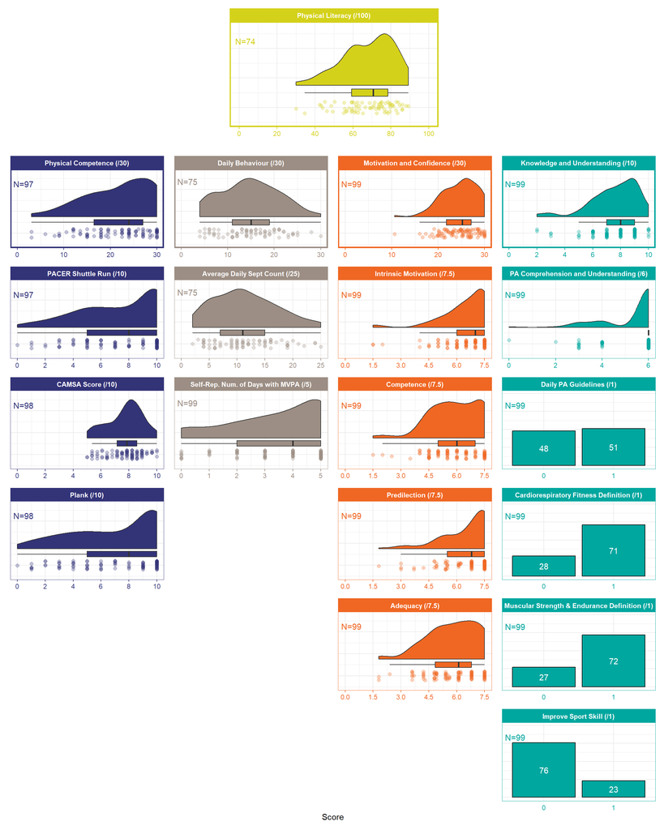

```r
p_capl_all_domains
```

#### 2.2.2 Tabular view

```r
desc_stats_capl_all |>
  gtsummary::as_flex_table() |>
  italic(i = 1, j = 2, part = "header") |>
  bold(i = c(1, 5, 8, 13, 19), j = 1:3)
```

| Score | N | Statistics1 |
| --- | --- | --- |
| Physical competence (/30) | 97 | 24.0 (16.5 - 27.0) 21.6 ± 7.0 |
| PACER shuttle run (/10) | 97 | 8.0 (5.0 - 10.0) 7.3 ± 2.8 |
| CAMSA (/10) | 98 | 7.9 (7.1 - 8.6) 7.7 ± 1.2 |
| Plank (/10) | 98 | 8.0 (5.0 - 10.0) 7.0 ± 3.1 |
| Daily behaviour (/30) | 75 | 15.0 (11.0 - 19.0) 14.8 ± 6.2 |
| Average daily step count (/25) | 75 | 11.0 (7.0 - 15.0) 11.5 ± 5.6 |
| Self-reported number of days with MVPA (/5) | 99 | 4.0 (2.0 - 5.0) 3.4 ± 1.7 |
| Motivation and confidence (/30) | 99 | 25.2 (21.7 - 27.1) 24.6 ± 3.8 |
| Intrinsic motivation (/7.5) | 99 | 7.0 (6.0 - 7.5) 6.4 ± 1.3 |
| Competence (/7.5) | 99 | 6.0 (5.0 - 7.0) 5.9 ± 1.3 |
| Predilection (/7.5) | 99 | 6.8 (5.5 - 7.5) 6.5 ± 1.3 |
| Adequacy (/7.5) | 99 | 6.1 (4.8 - 6.8) 5.8 ± 1.4 |
| Knowledge and understanding (/10) | 99 | 8.0 (7.0 - 9.0) 7.6 ± 1.7 |
| PA comprehension and understanding (/6) | 99 | 6.0 (6.0 - 6.0) 5.4 ± 1.2 |
| Daily PA guidelines (/1) | 99 | 51 (52%) |
| Cardiorespiratory fitness definition (/1) | 99 | 71 (72%) |
| Muscular strength and endurance definition (/1) | 99 | 72 (73%) |
| Improve sport skill (/1) | 99 | 23 (23%) |
| Physical literacy (/100) | 74 | 70.7 (59.3 - 78.5) 67.7 ± 13.4 |

1Median (Q1 - Q3), mean ± SD, or count (%) of participants who obtained a score of 1/1.

### 2.3 Interpretation category distributions

This section focuses only on the counts and percentages of participants associated to the different levels of interpretation (profile) provided by the CAPL-2 tool.

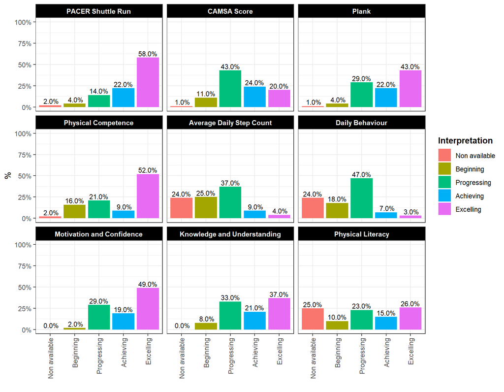

```r
p_interpretation
```

## 3 Between-sex comparisons of CAPL-2 scores

This part of the document proposes a detailed view of the CAPL-2 scores by sex. It has both a descriptive and an inferential purpose.

### 3.1 Score distributions

This section proposes graphical and numeric summaries of the CAPL-2 scores by sex.

#### 3.1.1 Graphical view

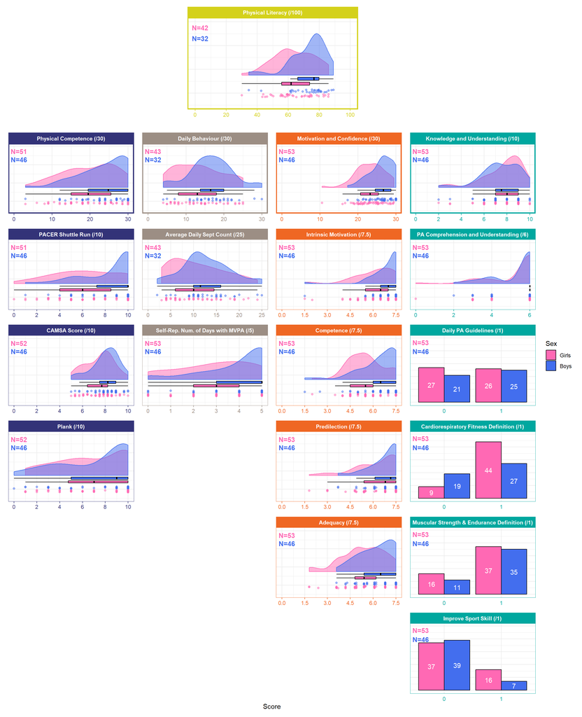

```r
p_capl_all_domains_by_sex
```

#### 3.1.2 Tabular view

```r
desc_stats_capl_by_sex |>
  gtsummary::as_flex_table() |>
  bold(i = c(1, 5, 8, 13, 19), j = 1:4)
```

| Score | All participants N = 991 | Girls N = 531 | Boys N = 461 |
| --- | --- | --- | --- |
| Physical competence (/30) | 24.0 (16.5 - 27.0) 21.6 ± 7.0 | 19.5 (15.0 - 25.5) 19.7 ± 7.1 | 24.8 (19.5 - 30.0) 23.7 ± 6.5 |
| PACER shuttle run (/10) | 8.0 (5.0 - 10.0) 7.3 ± 2.8 | 6.0 (4.0 - 9.0) 6.2 ± 2.8 | 10.0 (7.0 - 10.0) 8.5 ± 2.3 |
| CAMSA (/10) | 7.9 (7.1 - 8.6) 7.7 ± 1.2 | 7.7 (6.4 - 8.2) 7.5 ± 1.2 | 8.2 (7.5 - 8.9) 8.0 ± 1.2 |
| Plank (/10) | 8.0 (5.0 - 10.0) 7.0 ± 3.1 | 7.0 (4.5 - 10.0) 6.8 ± 3.0 | 9.0 (5.0 - 10.0) 7.3 ± 3.1 |
| Daily behaviour (/30) | 15.0 (11.0 - 19.0) 14.8 ± 6.2 | 13.0 (8.0 - 18.0) 13.5 ± 6.3 | 16.5 (13.5 - 20.0) 16.5 ± 5.8 |
| Average daily step count (/25) | 11.0 (7.0 - 15.0) 11.5 ± 5.6 | 10.0 (6.0 - 15.0) 10.6 ± 5.7 | 11.5 (10.0 - 16.0) 12.7 ± 5.3 |
| Self-reported number of days with MVPA (/5) | 4.0 (2.0 - 5.0) 3.4 ± 1.7 | 3.0 (2.0 - 4.0) 2.9 ± 1.6 | 5.0 (3.0 - 5.0) 3.9 ± 1.5 |
| Motivation and confidence (/30) | 25.2 (21.7 - 27.1) 24.6 ± 3.8 | 23.2 (20.7 - 25.4) 23.2 ± 3.8 | 26.7 (24.5 - 28.8) 26.2 ± 3.1 |
| Intrinsic motivation (/7.5) | 7.0 (6.0 - 7.5) 6.4 ± 1.3 | 6.5 (5.5 - 7.0) 6.1 ± 1.3 | 7.0 (6.5 - 7.5) 6.9 ± 1.0 |
| Competence (/7.5) | 6.0 (5.0 - 7.0) 5.9 ± 1.3 | 5.5 (4.5 - 6.0) 5.5 ± 1.2 | 6.5 (6.0 - 7.5) 6.3 ± 1.4 |
| Predilection (/7.5) | 6.8 (5.5 - 7.5) 6.5 ± 1.3 | 6.8 (5.4 - 7.5) 6.3 ± 1.4 | 7.2 (6.1 - 7.5) 6.8 ± 1.0 |
| Adequacy (/7.5) | 6.1 (4.8 - 6.8) 5.8 ± 1.4 | 5.4 (4.8 - 6.2) 5.4 ± 1.4 | 6.5 (5.4 - 7.5) 6.2 ± 1.1 |
| Knowledge and understanding (/10) | 8.0 (7.0 - 9.0) 7.6 ± 1.7 | 8.0 (7.0 - 9.0) 7.7 ± 1.8 | 7.5 (7.0 - 9.0) 7.5 ± 1.7 |
| PA comprehension and understanding (/6) | 6.0 (6.0 - 6.0) 5.4 ± 1.2 | 6.0 (6.0 - 6.0) 5.4 ± 1.3 | 6.0 (6.0 - 6.0) 5.4 ± 1.1 |
| Daily PA guidelines (/1) | 51 (52%) | 26 (49%) | 25 (54%) |
| Cardiorespiratory fitness definition (/1) | 71 (72%) | 44 (83%) | 27 (59%) |
| Muscular strength and endurance definition (/1) | 72 (73%) | 37 (70%) | 35 (76%) |
| Improve sport skill (/1) | 23 (23%) | 16 (30%) | 7 (15%) |
| Physical literacy (/100) | 70.7 (59.3 - 78.5) 67.7 ± 13.4 | 61.8 (55.7 - 73.8) 63.8 ± 13.2 | 76.5 (65.7 - 80.1) 72.9 ± 12.0 |

1Median (Q1 - Q3), mean ± SD, or count (%) of participants who obtained a score of 1/1.

### 3.2 Interpretation category distributions

This section focuses only on the counts and percentages of participants by sex associated to the different levels of interpretation (profile) provided by the CAPL-2 tool.

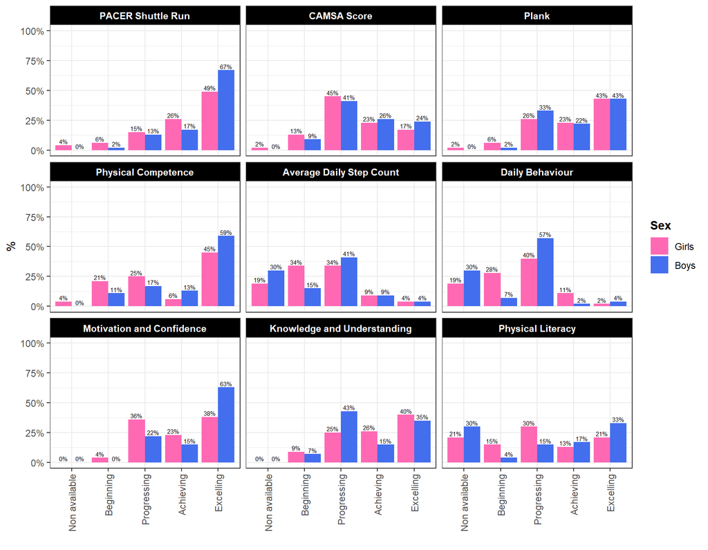

```r
p_interpretation_by_sex
```

### 3.3 Comparison of CAPL-2 global scores

The global comparison has been performed using a Brunner-Munzel test, that is a procedure testing the stochastic equality of the compared groups.

```r
capl_comp_sex
```

```
$Call
capl_score ~ gender
<environment: 0x000001f5e7432b90>

$Descriptive
     Sample Size
girl   girl   42
boy     boy   32

$Analysis
      Effect Estimator Std.Error      T Lower Upper p.Value
 p(girl,boy)     0.724    0.0612 3.6606 0.602 0.846   5e-04

$Studentized.Permutation
      Effect Estimator Std.Error      T  Lower  Upper p.Value
 p(girl,boy)     0.724    0.0612 3.6606 0.5976 0.8489   0.001

$Wilcoxon
      Effect Estimator Std.Error Statistic p.Value
 p(girl,boy)     0.724    0.0682    3.2843   0.001

$Shift.Effects
          Effect Estimator Lower Upper
 delta(boy-girl)      9.75   3.9  16.2

$plotting
$plotting$method
[1] "t.app"

$plotting$Effects
      Effect Estimator Std.Error      T Lower Upper p.Value
 p(girl,boy)     0.724    0.0612 3.6606 0.602 0.846   5e-04

$plotting$alpha
[1] 0.05


$output
$output$output.alternative
[1] "Relative Effect is unequal to 1/2"
```

[output cut: 13 more lines]

```
$output$info
[1] TRUE

$output$wilcoxon
[1] "asymptotic"

$output$alpha
[1] 0.05

$output$delta.interpretation
[1] "delta(.): Hodges-Lehmann Estimator"


attr(,"class")
[1] "ranktwosamples"
```

### 3.4 Comparison of CAPL-2 domain scores

#### 3.4.1 Graphical analysis

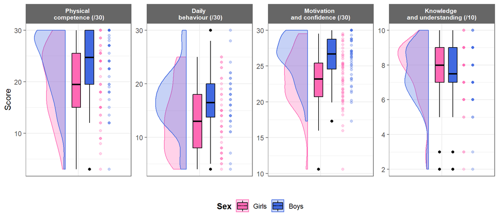

```r
p_multiv_comp_sex_dom
```

#### 3.4.2 Checking for multivariate outliers

```r
performance::check_outliers(
  capl_res |>
    dplyr::select(
      pc_score,
      db_score,
      mc_score,
      ku_score
      ) |>
    tidyr::drop_na(),
  method = "mcd") # recommended in DOI: 10.3758/s13428-024-02356-w
```

```
5 outliers detected: cases 5, 38, 61, 64, 73.
- Based on the following method and threshold: mcd (20).
- For variables: pc_score, db_score, mc_score, ku_score.
```

#### 3.4.3 Non-parametric multivariate analysis

The comparison of the multivariate distributions of domain scores between girls and boys has been performed using non-parametric analysis implemented in functions from the `{npmv}` package.

##### 3.4.3.1 R output for global comparison

###### 3.4.3.1.1 Raw output

```r
domain_global_multicomp_sex
```

```
$results
                                                  Test Statistic   df1      df2
ANOVA type test p-value                                    5.423 3.483 245.9092
McKeon approx. for the Lawley Hotelling Test                  NA    NA       NA
Muller approx. for the Bartlett-Nanda-Pillai Test             NA    NA       NA
Wilks Lambda                                                  NA    NA       NA
                                                  P-value
ANOVA type test p-value                             0.001
McKeon approx. for the Lawley Hotelling Test           NA
Muller approx. for the Bartlett-Nanda-Pillai Test      NA
Wilks Lambda                                           NA
                                                  Permutation Test p-value
ANOVA type test p-value                                              0.001
McKeon approx. for the Lawley Hotelling Test                            NA
Muller approx. for the Bartlett-Nanda-Pillai Test                       NA
Wilks Lambda                                                            NA

$twogroupreleffects
     pc_score db_score mc_score ku_score
girl  0.33556  0.36719  0.29278  0.57292
boy   0.66444  0.63281  0.70722  0.42708
```

###### 3.4.3.1.2 Formated output

```r
domain_global_multicomp_sex_rel_eff |>
  flextable() |>
  bold(i = 1, part = "header") |>
  bold( ~ `Rel. Eff. Girls` > 0.5, 4) |>
  bold( ~ `Rel. Eff. Boys` > 0.5, 5) |>
  bg( ~ `Rel. Eff. Girls` > 0.5, 4, bg = "grey90") |>
  bg( ~ `Rel. Eff. Boys` > 0.5, 5, bg = "grey90") |>
  width(j = 1, width = 2.5) |>
  width(j = 2, width = 1.5) |>
  width(j = 3, width = 1.5) |>
  valign(
    i = 1,
    j = 1:5,
    valign = "top",
    part = "header"
  ) |>
  align(j = 4:5, part = "header", align = "center") |>
  align(j = 4:5, part = "body", align = "center") |>
  add_footer_lines(
    "Min./ Max. Theo. Rel. Eff. = Minimum/maximum theoretical relative effect. A relative effect can be only between 0 and 1 and depicts the probability, for an individual randomly sampled from the considered group, to have a higher value than the one from an individual randomly sampled from both groups (girls and boys). Minimum and maximum theoretical relative effects are respectively the lowest and highest effect sizes than could be expected for a given group and score based on the number of girls and boys available for the considered score. Grey cells with bold values highlight the highest relative effects among girls and boys."
  )
```

| Score | N Girls (Min. / Max. Theo. Rel. Eff.) | N Boys (Min. / Max. Theo. Rel. Eff.) | Rel. Eff. Girls | Rel. Eff. Boys |
| --- | --- | --- | --- | --- |
| Physical competence (/30) | 51 (0.26/0.74) | 46 (0.24/0.76) | 0.34 | 0.66 |
| Daily behaviour (/30) | 43 (0.29/0.71) | 32 (0.21/0.79) | 0.37 | 0.63 |
| Motivation and confidence (/30) | 53 (0.27/0.73) | 46 (0.23/0.77) | 0.29 | 0.71 |
| Knowledge and understanding (/10) | 53 (0.27/0.73) | 46 (0.23/0.77) | 0.57 | 0.43 |

Min./ Max. Theo. Rel. Eff. = Minimum/maximum theoretical relative effect. A relative effect can be only between 0 and 1 and depicts the probability, for an individual randomly sampled from the considered group, to have a higher value than the one from an individual randomly sampled from both groups (girls and boys). Minimum and maximum theoretical relative effects are respectively the lowest and highest effect sizes than could be expected for a given group and score based on the number of girls and boys available for the considered score. Grey cells with bold values highlight the highest relative effects among girls and boys.

**Note**

The global analysis, based on the ANOVA type test p-value, suggests that girls and boys come from two different multivariate distributions related to the CAPL-2 domain scores. The `$twogroupreleffects` section of the R output shows the probability, for a given variable, that a girl or a boy randomly sampled respectively from girls or boys has a higher value than the one associated to a participant randomly sampled from both the girls and boys.

##### 3.4.3.2 R output for local comparisons

###### 3.4.3.2.1 Raw output

```r
cat(domain_local_multicomp_sex, sep = "\n")
```

```
The ANOVA type statistic will be used in the following test
The Global Hypothesis is significant, subset algorithm will continue

~Performing the Subset Algorithm based on Factor levels~
The Hypothesis of equality between factor levels  girl boy is rejected
All appropriate subsets using factor levels have been checked using a closed multiple testing procedure, which controls the maximum overall type I error rate at alpha= 0.05

~Performing the Subset Algorithm based on Response Variables~
 The Hypothesis of equality using response variables  pc_score db_score mc_score ku_score is rejected
The Hypothesis of equality using response variables  db_score mc_score ku_score is rejected
The Hypothesis of equality using response variables  pc_score mc_score ku_score is rejected
The Hypothesis of equality using response variables  pc_score db_score mc_score is rejected
The Hypothesis of equality using response variables  mc_score ku_score is rejected
The Hypothesis of equality using response variables  db_score mc_score is rejected
The Hypothesis of equality using response variables  pc_score mc_score is rejected
The Hypothesis of equality using response variables  mc_score is rejected
All appropriate subsets using response variables have been checked using a multiple testing procedure, which controls the maximum overall type I error rate at alpha= 0.05
```

###### 3.4.3.2.2 Graphical output

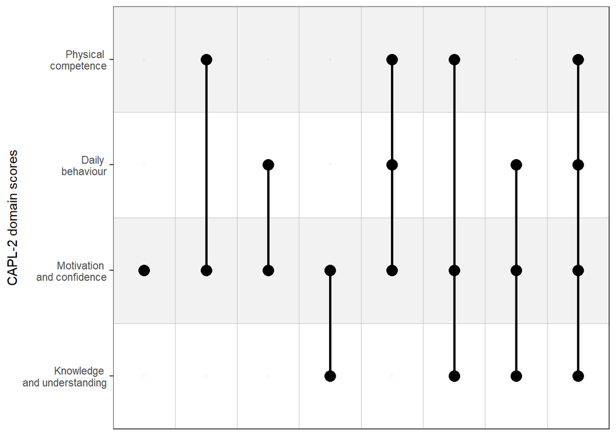

```r
domain_local_multicomp_sex_graph
```

### 3.5 Comparison of CAPL-2 item scores

#### 3.5.1 Graphical analysis

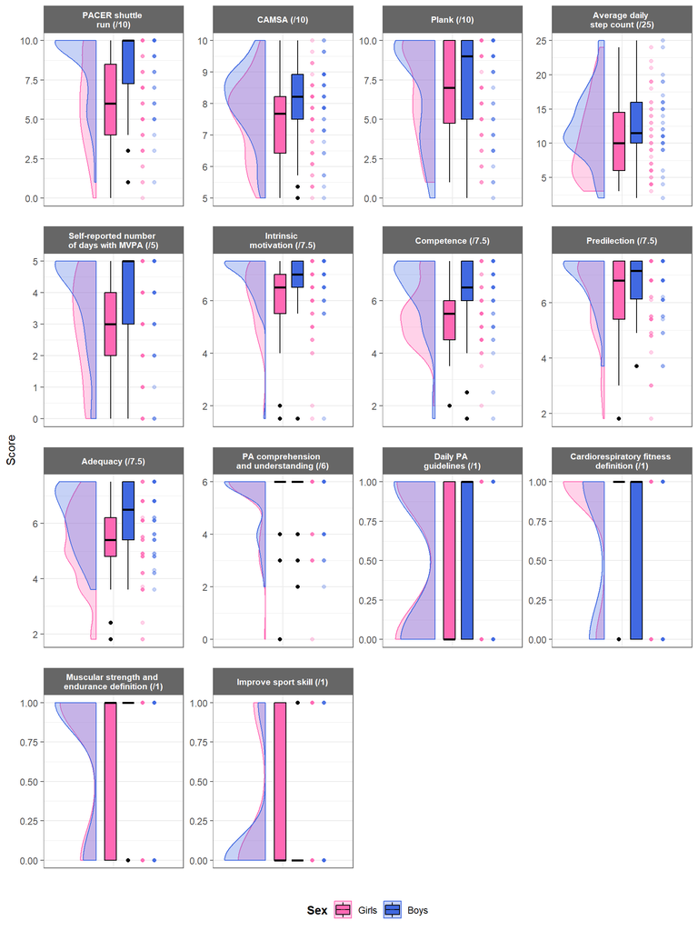

```r
p_multiv_comp_sex_item
```

#### 3.5.2 Checking for multivariate outliers

```r
performance::check_outliers(
  capl_res |> dplyr::select(
    pacer_score,
    plank_score,
    camsa_score,
    step_score,
    self_report_pa_score,
    predilection_score,
    adequacy_score,
    intrinsic_motivation_score,
    pa_competence_score,
    pa_guideline_score,
    crf_means_score,
    ms_means_score,
    sports_skill_score,
    fill_in_the_blanks_score
    ) |>
    tidyr::drop_na(),
  method = "mahalanobis_robust") # too many variables to use MCD method; alternative method chosen based on DOI: 10.3758/s13428-024-02356-w
```

```
13 outliers detected: cases 5, 9, 25, 29, 31, 38, 47, 57, 64, 65, 67,
  70, 73.
- Based on the following method and threshold: mahalanobis_robust (40).
- For variables: pacer_score, plank_score, camsa_score, step_score,
  self_report_pa_score, predilection_score, adequacy_score,
  intrinsic_motivation_score, pa_competence_score, pa_guideline_score,
  crf_means_score, ms_means_score, sports_skill_score,
  fill_in_the_blanks_score.
```

#### 3.5.3 R output for global comparison

The comparison of the multivariate distributions of item scores between girls and boys has been performed using non-parametric analysis implemented in functions from the `{npmv}` package.

##### 3.5.3.1 Raw output

```r
item_global_multicomp_sex
```

```
$results
                                                  Test Statistic    df1
ANOVA type test p-value                                    4.550  8.435
McKeon approx. for the Lawley Hotelling Test               2.142 14.000
Muller approx. for the Bartlett-Nanda-Pillai Test          2.113 14.148
Wilks Lambda                                               2.142 14.000
                                                       df2 P-value
ANOVA type test p-value                           595.6120   0.000
McKeon approx. for the Lawley Hotelling Test       59.0000   0.022
Muller approx. for the Bartlett-Nanda-Pillai Test  58.8177   0.024
Wilks Lambda                                       59.0000   0.022
                                                  Permutation Test p-value
ANOVA type test p-value                                              0.000
McKeon approx. for the Lawley Hotelling Test                         0.022
Muller approx. for the Bartlett-Nanda-Pillai Test                    0.022
Wilks Lambda                                                         0.022

$twogroupreleffects
     pacer_score camsa_score plank_score step_score self_report_pa_score
girl     0.29799     0.40551     0.42708    0.38765              0.31548
boy      0.70201     0.59449     0.57292    0.61235              0.68452
     intrinsic_motivation_score pa_competence_score predilection_score
girl                    0.31064             0.29985            0.44531
boy                     0.68936             0.70015            0.55469
     adequacy_score fill_in_the_blanks_score pa_guideline_score crf_means_score
girl        0.32626                  0.52418            0.46875          0.6317
boy         0.67374                  0.47582            0.53125          0.3683
     ms_means_score sports_skill_score
girl        0.47842            0.56101
boy         0.52158            0.43899
```

##### 3.5.3.2 Formated output

```r
item_global_multicomp_sex_rel_eff |>
  flextable() |>
  bold(i = 1, part = "header") |>
  bold( ~ `Rel. Eff. Girls` > 0.5, 4) |>
  bold( ~ `Rel. Eff. Boys` > 0.5, 5) |>
  bg( ~ `Rel. Eff. Girls` > 0.5, 4, bg = "grey90") |>
  bg( ~ `Rel. Eff. Boys` > 0.5, 5, bg = "grey90") |>
  width(j = 1, width = 2.5) |>
  width(j = 2, width = 1.5) |>
  width(j = 3, width = 1.5) |>
  valign(
    i = 1,
    j = 1:5,
    valign = "top",
    part = "header"
  ) |>
  align(j = 4:5, part = "header", align = "center") |>
  align(j = 4:5, part = "body", align = "center") |>
  add_footer_lines(
    "Min./ Max. Theo. Rel. Eff. = Minimum/maximum theoretical relative effect. A relative effect can be only between 0 and 1 and depicts the probability, for an individual randomly sampled from the considered group, to have a higher value than the one from an individual randomly sampled from both groups (girls and boys). Minimum and maximum theoretical relative effects are respectively the lowest and highest effect sizes than could be expected for a given group and score based on the number of girls and boys available for the considered score. Grey cells with bold values highlight the highest relative effects among girls and boys."
  )
```

| Score | N Girls (Min. / Max. Theo. Rel. Eff.) | N Boys (Min. / Max. Theo. Rel. Eff.) | Rel. Eff. Girls | Rel. Eff. Boys |
| --- | --- | --- | --- | --- |
| PACER shuttle run (/10) | 51 (0.26/0.74) | 46 (0.24/0.76) | 0.30 | 0.70 |
| CAMSA (/10) | 52 (0.27/0.73) | 46 (0.23/0.77) | 0.41 | 0.59 |
| Plank (/10) | 52 (0.27/0.73) | 46 (0.23/0.77) | 0.43 | 0.57 |
| Average daily step count (/25) | 43 (0.29/0.71) | 32 (0.21/0.79) | 0.39 | 0.61 |
| Self-reported number of days with MVPA (/5) | 53 (0.27/0.73) | 46 (0.23/0.77) | 0.32 | 0.68 |
| Intrinsic motivation (/7.5) | 53 (0.27/0.73) | 46 (0.23/0.77) | 0.31 | 0.69 |
| Competence (/7.5) | 53 (0.27/0.73) | 46 (0.23/0.77) | 0.30 | 0.70 |
| Predilection (/7.5) | 53 (0.27/0.73) | 46 (0.23/0.77) | 0.45 | 0.55 |
| Adequacy (/7.5) | 53 (0.27/0.73) | 46 (0.23/0.77) | 0.33 | 0.67 |
| PA comprehension and understanding (/6) | 53 (0.27/0.73) | 46 (0.23/0.77) | 0.52 | 0.48 |
| Daily PA guidelines (/1) | 53 (0.27/0.73) | 46 (0.23/0.77) | 0.47 | 0.53 |
| Cardiorespiratory fitness definition (/1) | 53 (0.27/0.73) | 46 (0.23/0.77) | 0.63 | 0.37 |
| Muscular strength and endurance definition (/1) | 53 (0.27/0.73) | 46 (0.23/0.77) | 0.48 | 0.52 |
| Improve sport skill (/1) | 53 (0.27/0.73) | 46 (0.23/0.77) | 0.56 | 0.44 |

Min./ Max. Theo. Rel. Eff. = Minimum/maximum theoretical relative effect. A relative effect can be only between 0 and 1 and depicts the probability, for an individual randomly sampled from the considered group, to have a higher value than the one from an individual randomly sampled from both groups (girls and boys). Minimum and maximum theoretical relative effects are respectively the lowest and highest effect sizes than could be expected for a given group and score based on the number of girls and boys available for the considered score. Grey cells with bold values highlight the highest relative effects among girls and boys.

**Note**

The global analysis, based on the ANOVA type test p-value, suggests that girls and boys come from two different multivariate distributions related to the CAPL-2 item scores. The `$twogroupreleffects` section of the R output shows the probability, for a given variable, that a girl or a boy randomly sampled respectively from girls or boys has a higher value than the one associated to a participant randomly sampled from both the girls and boys.

#### 3.5.4 R output for local comparisons

##### 3.5.4.1 Raw output

```r
cat(item_local_multicomp_sex, sep = "\n")
```

```
The ANOVA type statistic will be used in the following test
The Global Hypothesis is significant, subset algorithm will continue

~Performing the Subset Algorithm based on Factor levels~
The Hypothesis of equality between factor levels  girl boy is rejected
All appropriate subsets using factor levels have been checked using a closed multiple testing procedure, which controls the maximum overall type I error rate at alpha= 0.05

~Performing the Subset Algorithm based on Response Variables~
 The Hypothesis of equality using response variables  pacer_score camsa_score plank_score step_score self_report_pa_score intrinsic_motivation_score pa_competence_score predilection_score adequacy_score fill_in_the_blanks_score pa_guideline_score crf_means_score ms_means_score sports_skill_score is …
The Hypothesis of equality using response variables  camsa_score plank_score step_score self_report_pa_score intrinsic_motivation_score pa_competence_score predilection_score adequacy_score fill_in_the_blanks_score pa_guideline_score crf_means_score ms_means_score sports_skill_score is rejected
The Hypothesis of equality using response variables  pacer_score plank_score step_score self_report_pa_score intrinsic_motivation_score pa_competence_score predilection_score adequacy_score fill_in_the_blanks_score pa_guideline_score crf_means_score ms_means_score sports_skill_score is rejected
The Hypothesis of equality using response variables  pacer_score camsa_score step_score self_report_pa_score intrinsic_motivation_score pa_competence_score predilection_score adequacy_score fill_in_the_blanks_score pa_guideline_score crf_means_score ms_means_score sports_skill_score is rejected
The Hypothesis of equality using response variables  pacer_score camsa_score plank_score self_report_pa_score intrinsic_motivation_score pa_competence_score predilection_score adequacy_score fill_in_the_blanks_score pa_guideline_score crf_means_score ms_means_score sports_skill_score is rejected
The Hypothesis of equality using response variables  pacer_score camsa_score plank_score step_score intrinsic_motivation_score pa_competence_score predilection_score adequacy_score fill_in_the_blanks_score pa_guideline_score crf_means_score ms_means_score sports_skill_score is rejected
The Hypothesis of equality using response variables  pacer_score camsa_score plank_score step_score self_report_pa_score pa_competence_score predilection_score adequacy_score fill_in_the_blanks_score pa_guideline_score crf_means_score ms_means_score sports_skill_score is rejected
The Hypothesis of equality using response variables  pacer_score camsa_score plank_score step_score self_report_pa_score intrinsic_motivation_score predilection_score adequacy_score fill_in_the_blanks_score pa_guideline_score crf_means_score ms_means_score sports_skill_score is rejected
The Hypothesis of equality using response variables  pacer_score camsa_score plank_score step_score self_report_pa_score intrinsic_motivation_score pa_competence_score adequacy_score fill_in_the_blanks_score pa_guideline_score crf_means_score ms_means_score sports_skill_score is rejected
The Hypothesis of equality using response variables  pacer_score camsa_score plank_score step_score self_report_pa_score intrinsic_motivation_score pa_competence_score predilection_score fill_in_the_blanks_score pa_guideline_score crf_means_score ms_means_score sports_skill_score is rejected
The Hypothesis of equality using response variables  pacer_score camsa_score plank_score step_score self_report_pa_score intrinsic_motivation_score pa_competence_score predilection_score adequacy_score pa_guideline_score crf_means_score ms_means_score sports_skill_score is rejected
The Hypothesis of equality using response variables  pacer_score camsa_score plank_score step_score self_report_pa_score intrinsic_motivation_score pa_competence_score predilection_score adequacy_score fill_in_the_blanks_score crf_means_score ms_means_score sports_skill_score is rejected
The Hypothesis of equality using response variables  pacer_score camsa_score plank_score step_score self_report_pa_score intrinsic_motivation_score pa_competence_score predilection_score adequacy_score fill_in_the_blanks_score pa_guideline_score ms_means_score sports_skill_score is rejected
The Hypothesis of equality using response variables  pacer_score camsa_score plank_score step_score self_report_pa_score intrinsic_motivation_score pa_competence_score predilection_score adequacy_score fill_in_the_blanks_score pa_guideline_score crf_means_score sports_skill_score is rejected
The Hypothesis of equality using response variables  pacer_score camsa_score plank_score step_score self_report_pa_score intrinsic_motivation_score pa_competence_score predilection_score adequacy_score fill_in_the_blanks_score pa_guideline_score crf_means_score ms_means_score is rejected
The Hypothesis of equality using response variables  plank_score step_score self_report_pa_score intrinsic_motivation_score pa_competence_score predilection_score adequacy_score fill_in_the_blanks_score pa_guideline_score crf_means_score ms_means_score sports_skill_score is rejected
The Hypothesis of equality using response variables  camsa_score step_score self_report_pa_score intrinsic_motivation_score pa_competence_score predilection_score adequacy_score fill_in_the_blanks_score pa_guideline_score crf_means_score ms_means_score sports_skill_score is rejected
The Hypothesis of equality using response variables  camsa_score plank_score self_report_pa_score intrinsic_motivation_score pa_competence_score predilection_score adequacy_score fill_in_the_blanks_score pa_guideline_score crf_means_score ms_means_score sports_skill_score is rejected
```

[output cut: 2236 more lines]

##### 3.5.4.2 Graphical output

```r
item_local_multicomp_sex_graph
```

[figure not shown]

## 4 Between-physical literacy profile comparisons of movement behaviours

This part includes two subsections: a section showing the comparisons of the multivariate distributions of movement behaviour metrics between the physical literacy profiles; and a section showing the comparisons of the pattern of movement behaviours across the week between the physical literacy profiles. These analyses are based on data from participants having at least 4 valid days for the accelerometer-based measurement of movement behaviours and who had a valid CAPL-2 profile.

### 4.1 Data skimming

#### 4.1.1 Raw data

Navigation in the raw data (CAPL-2 scores along with movement behaviour metrics) is possible through the interactive table shown below.

```r
rmarkdown::paged_table(capl_res_4_valid_days)
```

| id | valid_days | wear_time | total_counts_axis1 | total_counts_vm | axis1_per_min | vm_per_min | minutes_SED | minutes_LPA | minutes_MVPA | percent_SED | percent_LPA | percent_MVPA | ratio_mvpa_sed | total_steps | max_steps_60min | max_steps_30min | max_steps_20min | max_steps_5min | max_steps_1min | peak_steps_60min | peak_steps_30min | peak_steps_20min | peak_steps_5min | peak_steps_1min | ig | M1/3 | M120 | M60 | M30 | … |
| --- | --- | --- | --- | --- | --- | --- | --- | --- | --- | --- | --- | --- | --- | --- | --- | --- | --- | --- | --- | --- | --- | --- | --- | --- | --- | --- | --- | --- | --- | --- |
| 3 | 4 | 761.00 | 323700.8 | 840508.2 | 430.83 | 1113.20 | 340.75 | 343.25 | 77.00 | 44.77 | 44.89 | 10.35 | 0.30 | 9002.50 | 39.52 | 57.06 | 73.35 | 95.20 | 115.25 | 76.16 | 90.17 | 96.10 | 109.05 | 115.25 | -2.96 | 39.26 | 624.61 | 906.02 | 1182.50 | … |
| 6 | 5 | 735.80 | 331134.0 | 731568.4 | 444.09 | 985.26 | 384.35 | 276.70 | 74.75 | 52.66 | 37.32 | 10.02 | 0.21 | 8857.00 | 41.91 | 61.21 | 74.58 | 100.96 | 118.40 | 76.25 | 89.25 | 95.54 | 111.04 | 118.40 | -2.83 | 10.95 | 580.30 | 929.52 | 1215.35 | … |
| 14 | 4 | 714.75 | 193732.0 | 550313.8 | 267.34 | 761.92 | 465.06 | 197.56 | 52.12 | 65.77 | 26.95 | 7.28 | 0.11 | 5292.25 | 26.47 | 36.19 | 41.74 | 79.30 | 108.25 | 47.17 | 60.84 | 69.59 | 92.90 | 108.25 | -2.89 | 0.00 | 449.79 | 779.38 | 1019.96 | … |
| 21 | 4 | 768.50 | 347427.5 | 872213.2 | 457.89 | 1134.79 | 309.31 | 387.44 | 71.75 | 40.82 | 49.73 | 9.45 | 0.24 | 8705.25 | 37.50 | 53.42 | 58.26 | 98.20 | 117.50 | 65.01 | 80.61 | 88.84 | 108.35 | 117.50 | -2.65 | 52.82 | 619.76 | 937.78 | 1254.43 | … |
| 22 | 5 | 811.20 | 240924.0 | 749892.3 | 295.06 | 920.12 | 312.15 | 457.80 | 41.25 | 38.59 | 56.36 | 5.05 | 0.13 | 5924.40 | 22.03 | 30.43 | 34.74 | 55.48 | 88.20 | 42.47 | 52.73 | 57.91 | 73.60 | 88.20 | -2.86 | 56.49 | 509.62 | 731.41 | 961.44 | … |
| 23 | 4 | 671.75 | 397854.5 | 982462.0 | 582.57 | 1444.40 | 238.56 | 340.56 | 92.62 | 36.14 | 50.26 | 13.59 | 0.49 | 8884.50 | 32.57 | 46.83 | 55.61 | 93.15 | 125.25 | 64.87 | 79.70 | 87.61 | 112.15 | 125.25 | -2.44 | 45.76 | 697.69 | 1092.59 | 1452.38 | … |
| 25 | 5 | 836.20 | 582088.4 | 1573639.7 | 686.42 | 1859.31 | 243.10 | 431.15 | 161.95 | 29.84 | 51.07 | 19.09 | 0.69 | 12044.80 | 40.72 | 54.99 | 61.93 | 103.68 | 123.20 | 69.15 | 83.70 | 92.25 | 114.96 | 123.20 | -2.51 | 187.37 | 1003.39 | 1363.01 | 1744.99 | … |
| 27 | 4 | 797.25 | 400899.2 | 1025237.9 | 492.90 | 1263.55 | 302.50 | 392.44 | 102.31 | 38.66 | 48.81 | 12.53 | 0.36 | 9084.25 | 37.08 | 50.10 | 58.24 | 100.45 | 119.75 | 65.10 | 81.18 | 91.05 | 111.20 | 119.75 | -2.82 | 70.37 | 749.90 | 1087.31 | 1355.43 | … |
| 28 | 4 | 789.25 | 523203.2 | 1141145.3 | 683.41 | 1485.01 | 326.50 | 345.25 | 117.50 | 41.16 | 43.34 | 15.51 | 0.38 | 12836.25 | 58.72 | 75.18 | 86.05 | 109.40 | 143.00 | 89.35 | 102.72 | 109.08 | 129.10 | 143.00 | -2.42 | 32.25 | 848.95 | 1214.50 | 1551.39 | … |
| 32 | 4 | 793.00 | 462422.2 | 1221121.2 | 586.07 | 1551.33 | 194.25 | 494.44 | 104.31 | 24.18 | 62.48 | 13.33 | 0.64 | 11735.50 | 41.36 | 59.21 | 72.00 | 118.85 | 140.75 | 86.02 | 102.31 | 109.86 | 129.45 | 140.75 | -2.59 | 134.57 | 801.42 | 1138.00 | 1470.92 | … |

[output cut: 40 more lines]

#### 4.1.2 Variable summaries

This section proposes an overview of the study dataset related to both the valid CAPL-2 profiles and the movement behaviour metrics in the participants with at least 4 valid days for the accelerometer-based measurement of movement behaviours. More precisely, the tables display information about the dataset structure as well as descriptive statistics for all the variables from the dataset. The interest of this section is mainly to verify that all the variables have been correctly formated and to have information about potential missing values.

```r
skimr::skim(capl_res_4_valid_days)
```

Data summary

| Name | capl_res_4_valid_days |
| --- | --- |
| Number of rows | 50 |
| Number of columns | 144 |
| _______________________ |  |
| Column type frequency: |  |
| factor | 30 |
| numeric | 114 |
| ________________________ |  |
| Group variables | None |

**Variable type: factor**

| skim_variable | n_missing | complete_rate | ordered | n_unique | top_counts |
| --- | --- | --- | --- | --- | --- |
| school | 0 | 1.00 | FALSE | 6 | BOI: 13, JEA: 10, SAI: 10, SAI: 9 |
| gender | 0 | 1.00 | FALSE | 2 | gir: 25, boy: 25 |
| time_on1 | 0 | 1.00 | FALSE | 1 | 06:: 50 |
| time_on2 | 0 | 1.00 | FALSE | 1 | 06:: 50 |
| time_on3 | 0 | 1.00 | FALSE | 1 | 06:: 50 |
| time_on4 | 0 | 1.00 | FALSE | 1 | 06:: 50 |
| time_on5 | 0 | 1.00 | FALSE | 1 | 06:: 50 |
| time_on6 | 0 | 1.00 | FALSE | 1 | 06:: 50 |
| time_on7 | 0 | 1.00 | FALSE | 1 | 06:: 50 |
| time_off1 | 0 | 1.00 | FALSE | 47 | 16:: 2, 18:: 2, 18:: 2, 10:: 1 |
| time_off2 | 0 | 1.00 | FALSE | 45 | 18:: 3, 17:: 2, 18:: 2, 18:: 2 |
| time_off3 | 0 | 1.00 | FALSE | 47 | 19:: 2, 20:: 2, 20:: 2, 14:: 1 |
| time_off4 | 0 | 1.00 | FALSE | 47 | 18:: 2, 19:: 2, 20:: 2, 06:: 1 |
| time_off5 | 0 | 1.00 | FALSE | 48 | 17:: 2, 18:: 2, 06:: 1, 06:: 1 |
| time_off6 | 0 | 1.00 | FALSE | 49 | 18:: 2, 06:: 1, 06:: 1, 06:: 1 |
| time_off7 | 14 | 0.72 | FALSE | 34 | 10:: 2, 13:: 2, 06:: 1, 06:: 1 |
| pacer_interpretation | 0 | 1.00 | FALSE | 4 | Exc: 29, Ach: 11, Pro: 8, Beg: 2 |
| plank_interpretation | 0 | 1.00 | FALSE | 4 | Exc: 26, Pro: 15, Ach: 8, Beg: 1 |
| camsa_interpretation | 0 | 1.00 | FALSE | 4 | Pro: 22, Ach: 11, Exc: 11, Beg: 6 |
| pc_interpretation | 0 | 1.00 | FALSE | 4 | Exc: 26, Pro: 10, Beg: 8, Ach: 6 |
| pc_status | 0 | 1.00 | FALSE | 1 | com: 50, inc: 0 |
| step_interpretation | 0 | 1.00 | FALSE | 4 | Pro: 28, Beg: 14, Ach: 7, Exc: 1 |
| db_interpretation | 0 | 1.00 | FALSE | 4 | Pro: 36, Beg: 8, Ach: 5, Exc: 1 |
| db_status | 0 | 1.00 | FALSE | 1 | com: 50, inc: 0 |
| mc_interpretation | 0 | 1.00 | FALSE | 3 | Exc: 28, Pro: 14, Ach: 8, Non: 0 |
| mc_status | 0 | 1.00 | FALSE | 1 | com: 50, inc: 0 |
| ku_interpretation | 0 | 1.00 | FALSE | 4 | Pro: 19, Exc: 19, Ach: 9, Beg: 3 |
| ku_status | 0 | 1.00 | FALSE | 1 | com: 50 |
| capl_interpretation | 0 | 1.00 | FALSE | 4 | Exc: 22, Pro: 14, Ach: 9, Beg: 5 |
| capl_status | 0 | 1.00 | FALSE | 1 | com: 50, inc: 0, mis: 0 |

**Variable type: numeric**

| skim_variable | n_missing | complete_rate | mean | sd | p0 | p25 | p50 | p75 | p100 | hist |
| --- | --- | --- | --- | --- | --- | --- | --- | --- | --- | --- |
| id | 0 | 1.00 | 80.06 | 47.81 | 3.00 | 39.50 | 72.50 | 131.25 | 154.00 | ▆▇▃▃▇ |
| valid_days | 0 | 1.00 | 4.94 | 0.82 | 4.00 | 4.00 | 5.00 | 6.00 | 6.00 | ▇▁▇▁▇ |
| wear_time | 0 | 1.00 | 767.63 | 47.99 | 671.75 | 731.82 | 764.65 | 798.38 | 920.00 | ▅▇▇▁▁ |
| total_counts_axis1 | 0 | 1.00 | 389677.95 | 121578.71 | 188973.33 | 292359.90 | 378799.88 | 482476.50 | 724679.40 | ▆▇▆▃▁ |
| total_counts_vm | 0 | 1.00 | 930013.63 | 235810.56 | 511979.16 | 733304.05 | 929101.50 | 1102564.58 | 1573639.74 | ▆▇▇▃▁ |
| axis1_per_min | 0 | 1.00 | 510.04 | 161.89 | 262.39 | 385.32 | 467.38 | 613.57 | 994.88 | ▇▇▇▂▁ |
| vm_per_min | 0 | 1.00 | 1214.23 | 299.85 | 712.75 | 969.82 | 1195.31 | 1465.02 | 1859.31 | ▆▇▆▆▃ |
| minutes_SED | 0 | 1.00 | 331.36 | 69.69 | 194.25 | 280.26 | 326.77 | 380.91 | 492.38 | ▃▆▇▅▂ |
| minutes_LPA | 0 | 1.00 | 351.26 | 61.93 | 197.56 | 307.91 | 343.64 | 394.73 | 494.44 | ▁▆▇▇▂ |
| minutes_MVPA | 0 | 1.00 | 85.01 | 29.98 | 21.40 | 63.64 | 83.06 | 103.83 | 161.95 | ▃▇▆▅▂ |
| percent_SED | 0 | 1.00 | 43.22 | 8.88 | 24.18 | 37.49 | 41.88 | 50.26 | 65.77 | ▃▇▇▆▁ |
| percent_LPA | 0 | 1.00 | 45.66 | 7.35 | 26.95 | 41.08 | 45.56 | 51.05 | 62.48 | ▁▅▇▇▂ |
| percent_MVPA | 0 | 1.00 | 11.12 | 3.87 | 2.76 | 8.78 | 10.59 | 13.88 | 19.09 | ▃▇▇▅▅ |
| ratio_mvpa_sed | 0 | 1.00 | 0.31 | 0.16 | 0.09 | 0.17 | 0.28 | 0.41 | 0.72 | ▇▅▅▃▁ |
| total_steps | 0 | 1.00 | 9691.26 | 2465.20 | 5292.25 | 8227.58 | 9402.15 | 11584.56 | 15216.80 | ▅▇▅▆▂ |
| max_steps_60min | 0 | 1.00 | 42.89 | 11.19 | 22.03 | 36.98 | 42.17 | 50.19 | 73.22 | ▃▇▆▃▁ |
| max_steps_30min | 0 | 1.00 | 56.43 | 12.99 | 30.43 | 49.04 | 56.16 | 64.39 | 97.07 | ▃▇▇▂▁ |
| max_steps_20min | 0 | 1.00 | 65.80 | 13.75 | 34.74 | 56.14 | 65.35 | 74.27 | 103.02 | ▂▅▇▁▁ |
| max_steps_5min | 0 | 1.00 | 99.84 | 15.11 | 55.48 | 92.23 | 101.76 | 109.52 | 130.15 | ▁▂▅▇▂ |
| max_steps_1min | 0 | 1.00 | 125.42 | 14.39 | 88.20 | 117.00 | 125.90 | 134.00 | 158.75 | ▁▃▇▇▁ |
| peak_steps_60min | 0 | 1.00 | 72.19 | 13.62 | 42.47 | 64.90 | 73.17 | 79.88 | 109.45 | ▃▇▇▃▁ |
| peak_steps_30min | 0 | 1.00 | 87.34 | 14.05 | 52.73 | 79.16 | 89.28 | 97.43 | 117.63 | ▂▂▇▆▂ |
| peak_steps_20min | 0 | 1.00 | 94.97 | 14.05 | 57.91 | 87.92 | 96.17 | 104.37 | 123.74 | ▁▃▇▇▂ |
| peak_steps_5min | 0 | 1.00 | 114.24 | 14.01 | 73.60 | 108.52 | 114.58 | 123.22 | 142.15 | ▁▂▇▇▂ |
| peak_steps_1min | 0 | 1.00 | 125.42 | 14.39 | 88.20 | 117.00 | 125.90 | 134.00 | 158.75 | ▁▃▇▇▁ |
| ig | 0 | 1.00 | -2.77 | 0.21 | -3.32 | -2.87 | -2.77 | -2.63 | -2.24 | ▁▂▇▃▁ |
| M1/3 | 0 | 1.00 | 44.22 | 36.89 | 0.00 | 15.54 | 39.53 | 59.95 | 187.37 | ▇▇▂▁▁ |
| M120 | 0 | 1.00 | 676.62 | 144.46 | 406.82 | 549.61 | 659.14 | 792.44 | 1003.39 | ▆▇▇▆▂ |
| M60 | 0 | 1.00 | 1004.33 | 214.32 | 624.25 | 866.06 | 972.00 | 1128.30 | 1814.89 | ▃▇▃▁▁ |
| M30 | 0 | 1.00 | 1308.18 | 295.34 | 763.26 | 1150.52 | 1262.16 | 1453.00 | 2513.24 | ▃▇▃▁▁ |

[output cut: 84 more lines]

### 4.2 Distributions of the movement behaviour metrics

This section shows the distributions of the movement behaviour metrics that were deemed of potential interest for exploratory analysis. These metrics were directly available from the {activAnalyzer} package. Some metrics have been removed from the initial list of the available metrics. MPA and VPA minutes and related percentages of wear time have been removed because we had no tresholds to make a distinction between moderate and vigorous physical activity in children. Total kilocalories, physical activity level, and MVPA MET-hours have been removed because they were not based on children-specific equations (no appropriate equations were available in the {activAnalyzer} package) and there was also no consideration for these metrics that are usually poorly estimated. The retained metrics represent different movement behaviour concepts: activity volume, step accumulation, intensity distribution, and sedentary time accumulation pattern. Details about what the metrics mean are available in the manual of the {activAnalyzer} package. Of note, in the figure below, the list of the metrics that goes from `Wear time (min)` to `Number of breaks` represent daily means while the remaining metrics were computed considering the whole set of valid days of measurement.

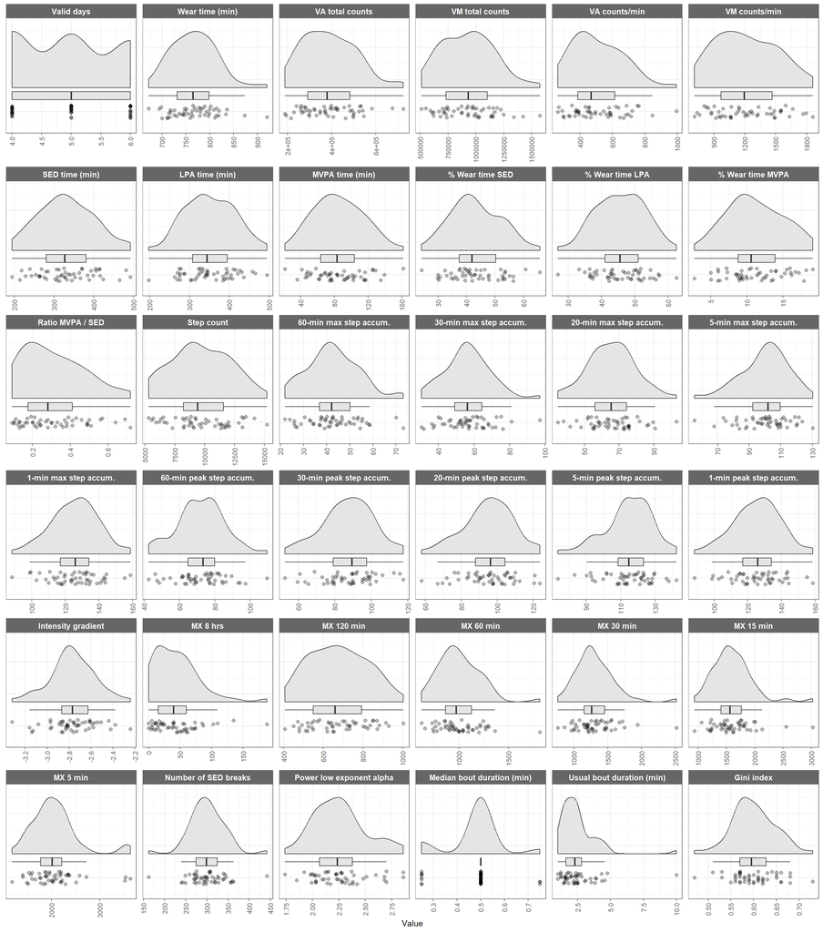

```r
p_distri_all_metrics
```

### 4.3 Vizualisation of the (un)correlated movement behaviour variables based on Principal Component Analysis

As there were a lot of variables available to characterize movement behaviours, we conducted a principal component analysis (PCA) to evaluate to what extent the initial set of variables could be reduced. The rationale for variable selection was to have at least one variable for each of the movement behaviour concepts presented above while keeping the variables that were not perfectly or not too strongly correlated (strongly correlated variables could be observed on a PCA biplot with arrows that would point to the same direction or to opposite directions). For the variables related to activity volume, only the vector magnitude counts/min, the percentages of wear time spent sedentary or in light/moderate-to-vigorous physical activity, the step count and the MVPA / SED ratio were considered during PCA.

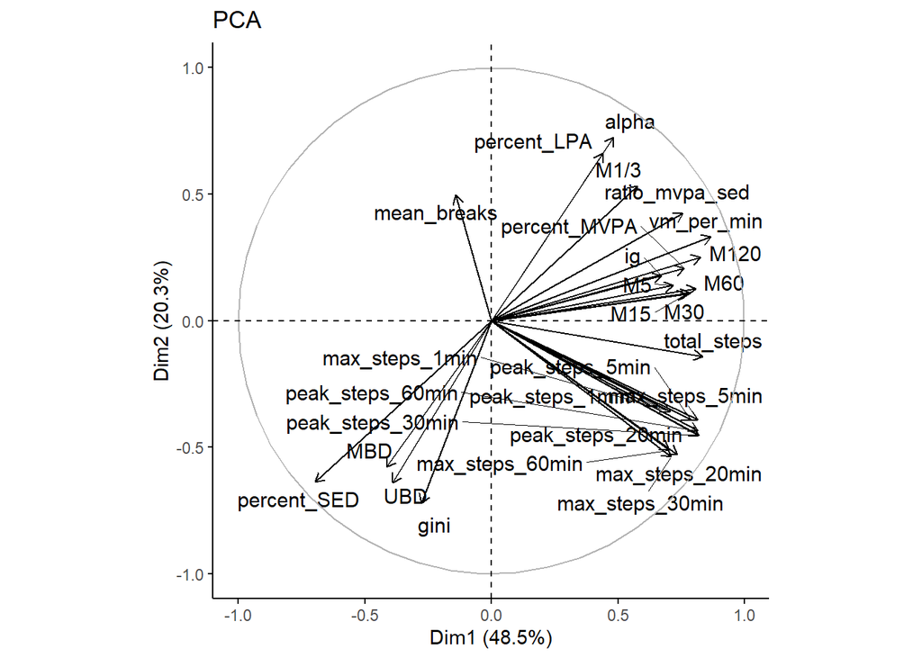

```r
p_biplot_metrics
```

**Note**

Based on the PCA biplot, we kept for further analysis:

- For activity volume metrics:
  - `vm_perm_min`
  - `percent_SED`
  - `percent_LPA`
  - `percent_MVPA`
  - `total_steps`
- For step accumulation metrics:
  - `max_steps_60min`
  - `peak_steps_60min`
- For intensity distribution metrics:
  - `ig`
- For sedentary behaviour accumulation metrics:
  - `mean_breaks`
  - `UBD`
  - `gini`

### 4.4 Checking of the correlations between the retained variables

```r
check_cor_metrics
```

```
         Parameter1       Parameter2          rho   CI      CI_low      CI_high
1               UBD             gini  0.949404541 0.95  0.91065820  0.971596911
2        vm_per_min     percent_MVPA  0.949195678 0.95  0.91029675  0.971478321
3       percent_SED      percent_LPA -0.890132053 0.95 -0.93748907 -0.810409010
4   max_steps_60min peak_steps_60min  0.856614646 0.95  0.75571383  0.917790491
5       percent_LPA              UBD -0.855400282 0.95 -0.91707110 -0.753758253
6       total_steps peak_steps_60min  0.840672269 0.95  0.73018313  0.908314084
7       percent_SED              UBD  0.829323348 0.95  0.71219463  0.901525526
8       total_steps  max_steps_60min  0.795726291 0.95  0.65982866  0.881218335
9        vm_per_min      percent_SED -0.764705882 0.95 -0.86218413 -0.612623083
10       vm_per_min               ig  0.753651886 0.95  0.59605975  0.855334199
11      percent_LPA             gini -0.749692628 0.95 -0.85287205 -0.590159633
12       vm_per_min      total_steps  0.741560624 0.95  0.57809447  0.847800561
13     percent_MVPA               ig  0.737651499 0.95  0.57231997  0.845355716
14      percent_SED             gini  0.693477734 0.95  0.50818712  0.817411401
```

[output cut: 97 more lines]

**Note**

Based on the correlation results, we finally removed `vm_perm_min`, `percent_LPA`, `peak_steps_60min` and `gini` to keep variables with lower correlations. The final list of the retained metrics is the following:

- For activity volume metrics:
  - `percent_SED`
  - `percent_MVPA`
  - `total_steps`
- For step accumulation metrics:
  - `max_steps_60min`
- For intensity distribution metrics:
  - `ig`
- For sedentary behaviour accumulation metrics:
  - `mean_breaks`
  - `UBD`

### 4.5 Checking for multivariate outliers

```r
performance::check_outliers(
  capl_res_4_valid_days |>
    dplyr::select(tidyselect::any_of(selected_metrics$raw_names)),
  method = "mahalanobis_robust") # too many variables to use MCD method; alternative method chosen based on DOI: 10.3758/s13428-024-02356-w
```

```
7 outliers detected: cases 3, 5, 19, 35, 38, 43, 45.
- Based on the following method and threshold: mahalanobis_robust
  (24.322).
- For variables: percent_SED, percent_MVPA, total_steps,
  max_steps_60min, ig, mean_breaks, UBD.
```

### 4.6 Non-parametric multivariate analysis

#### 4.6.1 Graphical analysis

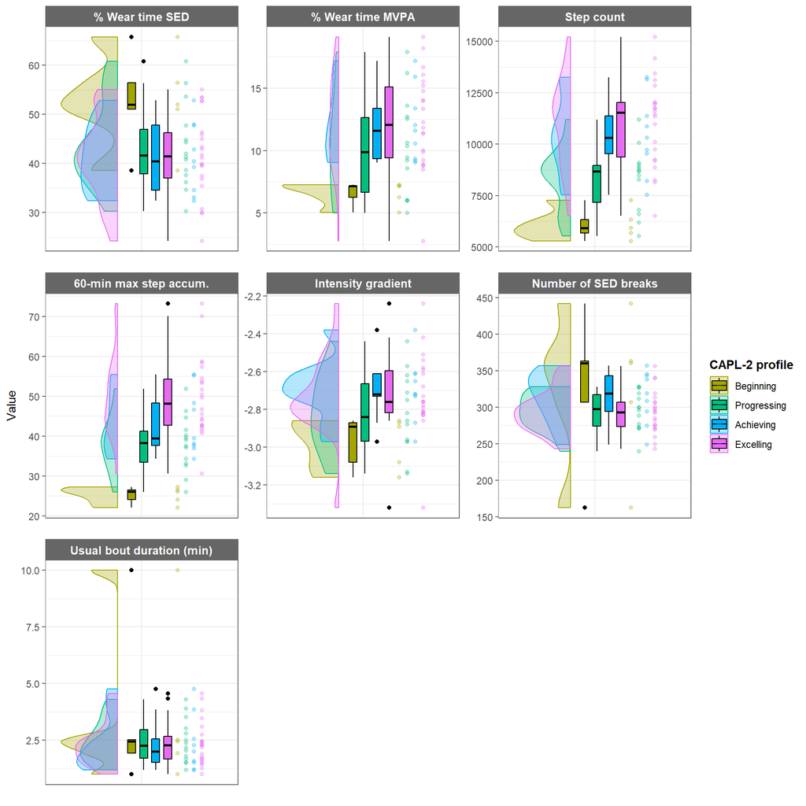

```r
p_distri_all_metrics_by_profile
```

#### 4.6.2 Tabular view

```r
tbl_retained_metrics |>
  gtsummary::as_flex_table()
```

| Metric | All participants N = 501 | Beginning N = 51 | Progressing N = 141 | Achieving N = 91 | Excelling N = 221 |
| --- | --- | --- | --- | --- | --- |
| % Wear time SED | 41.9 (37.5 - 51.1) 43.2 ± 8.9 | 52.0 (51.1 - 56.4) 52.8 ± 9.8 | 41.6 (37.6 - 47.7) 43.5 ± 8.6 | 40.5 (34.5 - 47.8) 41.2 ± 7.2 | 41.5 (36.8 - 46.4) 41.7 ± 8.6 |
| % Wear time MVPA | 10.6 (8.8 - 14.0) 11.1 ± 3.9 | 7.2 (6.3 - 7.2) 6.6 ± 1.0 | 9.9 (6.0 - 12.7) 10.3 ± 3.9 | 11.6 (9.3 - 13.4) 12.0 ± 3.0 | 12.1 (9.3 - 15.2) 12.3 ± 3.8 |
| Step count | 9,402.2 (8,216.6 - 11,624.3) 9,691.3 ± 2,465.2 | 5,924.4 (5,682.8 - 6,341.0) 6,104.8 ± 760.9 | 8,688.4 (6,813.7 - 9,002.5) 8,306.9 ± 1,536.5 | 10,319.8 (9,542.5 - 11,378.3) 10,442.5 ± 1,965.2 | 11,544.9 (9,261.8 - 12,044.8) 11,080.0 ± 2,129.4 |
| 60-min max step accum. | 42.2 (37.0 - 50.4) 42.9 ± 11.2 | 26.1 (24.1 - 26.5) 25.2 ± 2.1 | 38.3 (33.1 - 41.6) 38.0 ± 6.9 | 39.4 (37.6 - 48.3) 43.5 ± 8.1 | 48.2 (42.6 - 54.5) 49.7 ± 9.9 |
| Intensity gradient | -2.8 (-2.9 - -2.6) -2.8 ± 0.2 | -2.9 (-3.1 - -2.9) -3.0 ± 0.1 | -2.8 (-3.0 - -2.7) -2.8 ± 0.2 | -2.7 (-2.7 - -2.6) -2.7 ± 0.2 | -2.8 (-2.8 - -2.6) -2.7 ± 0.2 |
| Number of SED breaks | 298.7 (274.5 - 326.0) 300.6 ± 42.2 | 360.2 (306.5 - 363.0) 326.8 ± 103.9 | 297.5 (272.8 - 318.8) 294.7 ± 26.4 | 319.0 (294.2 - 342.8) 314.1 ± 36.2 | 292.9 (272.8 - 306.8) 292.9 ± 29.0 |
| Usual bout duration (min) | 2.3 (1.6 - 2.8) 2.5 ± 1.5 | 2.5 (1.9 - 2.5) 3.6 ± 3.6 | 2.3 (1.7 - 3.0) 2.5 ± 1.0 | 2.0 (1.5 - 2.6) 2.3 ± 1.2 | 2.3 (1.7 - 2.7) 2.4 ± 1.0 |

1Numbers are medians (Q1 - Q3) and means ± SD. SED = sedentary, MVPA = moderate-to-vigorous physical activity. All metrics are daily averages except usual bout duration that was based on the entire week of measurement.

#### 4.6.3 Checking sex distribution across physical literacy profiles

We check that girls and boys were approximately equally distributed across the physical literacy profiles so that potential differences bewteen the profiles are not confounded by sex differences.

```r
tar_read(capl_res_4_valid_days) |>
  dplyr::count(capl_interpretation, gender) |>
  tidyr::pivot_wider(names_from = gender, values_from = n)
```

```
# A tibble: 4 × 3
  capl_interpretation  girl   boy
  <fct>               <int> <int>
1 Beginning               3     2
2 Progressing             8     6
3 Achieving               4     5
4 Excelling              10    12
```

**Note**

The distribution of girls and boys was quite balanced across the physical literacy profiles.

#### 4.6.4 R output for global comparison

The comparisons of the multivariate distributions of movement behaviour metrics between physical literacy profiles have been performed using non-parametric analysis implemented in functions from the `{npmv}` package.

##### 4.6.4.1 Raw output

```r
metrics_global_multicomp_profile
```

```
$results
                                                  Test Statistic    df1
ANOVA type test p-value                                    5.300  7.952
McKeon approx. for the Lawley Hotelling Test               2.989 21.000
Muller approx. for the Bartlett-Nanda-Pillai Test          2.400 22.901
Wilks Lambda                                               2.705 21.000
                                                       df2 P-value
ANOVA type test p-value                            84.9015   0.000
McKeon approx. for the Lawley Hotelling Test       77.2245   0.000
Muller approx. for the Bartlett-Nanda-Pillai Test 134.6599   0.001
Wilks Lambda                                      115.4085   0.000
                                                  Permutation Test p-value
ANOVA type test p-value                                                  0
McKeon approx. for the Lawley Hotelling Test                             0
Muller approx. for the Bartlett-Nanda-Pillai Test                        0
Wilks Lambda                                                             0

$releffects
            percent_SED percent_MVPA total_steps max_steps_60min      ig
Beginning       0.75000      0.13800     0.08600         0.06200 0.16800
Progressing     0.50857      0.44000     0.33000         0.35714 0.42500
Achieving       0.43667      0.57667     0.58778         0.51222 0.61333
Excelling       0.46364      0.58909     0.66636         0.68545 0.57682
            mean_breaks     UBD
Beginning       0.70200 0.54000
Progressing     0.45857 0.52500
Achieving       0.62222 0.45000
Excelling       0.43045 0.49545
```

##### 4.6.4.2 Formated output

```r
metrics_global_multicomp_profile_rel_eff |>
  flextable() |>
  bold(i = 1, part = "header") |>
  bold( ~ `Rel. Eff. Beginning` > 0.5, 6) |>
  bold( ~ `Rel. Eff. Progressing` > 0.5, 7) |>
  bold( ~ `Rel. Eff. Achieving` > 0.5, 8) |>
  bold( ~ `Rel. Eff. Excelling` > 0.5, 9) |>
  bg( ~ `Rel. Eff. Beginning` > 0.5, 6, bg = "grey90") |>
  bg( ~ `Rel. Eff. Progressing` > 0.5, 7, bg = "grey90") |>
  bg( ~ `Rel. Eff. Achieving` > 0.5, 8, bg = "grey90") |>
  bg( ~ `Rel. Eff. Excelling` > 0.5, 9, bg = "grey90") |>
  width(j = 1, width = 2.5) |>
  width(j = 2:9, width = 1.3) |>
  valign(
    i = 1,
    j = 1:9,
    valign = "top",
    part = "header"
  ) |>
  align(j = 6:9, part = "header", align = "center") |>
  align(j = 6:9, part = "body", align = "center") |>
  add_footer_lines(
    "Min./ Max. Theo. Rel. Eff. = Minimum/maximum theoretical relative effect. A relative effect can be only between 0 and 1 and depicts the probability, for an individual randomly sampled from the considered group, to have a higher value than the one from an individual randomly sampled from all groups (all physical literacy profiles). Minimum and maximum theoretical relative effects are respectively the lowest and highest effect sizes than could be expected for a given group and metric based on the number of participants available for the considered metric. Grey cells with bold values highlight the highest relative effects among the physical literacy profiles."
  )
```

| Metric | N Beginning (Min. / Max. Theo. Rel. Eff.) | N Progressing (Min. / Max. Theo. Rel. Eff.) | N Achieving (Min. / Max. Theo. Rel. Eff.) | N Excelling (Min. / Max. Theo. Rel. Eff.) | Rel. Eff. Beginning | Rel. Eff. Progressing | Rel. Eff. Achieving | Rel. Eff. Excelling |
| --- | --- | --- | --- | --- | --- | --- | --- | --- |
| % Wear time SED | 5 (0.05/0.95) | 14 (0.14/0.86) | 9 (0.09/0.91) | 22 (0.22/0.78) | 0.75 | 0.51 | 0.44 | 0.46 |
| % Wear time MVPA | 5 (0.05/0.95) | 14 (0.14/0.86) | 9 (0.09/0.91) | 22 (0.22/0.78) | 0.14 | 0.44 | 0.58 | 0.59 |
| Step count | 5 (0.05/0.95) | 14 (0.14/0.86) | 9 (0.09/0.91) | 22 (0.22/0.78) | 0.09 | 0.33 | 0.59 | 0.67 |
| 60-min max step accum. | 5 (0.05/0.95) | 14 (0.14/0.86) | 9 (0.09/0.91) | 22 (0.22/0.78) | 0.06 | 0.36 | 0.51 | 0.69 |
| Intensity gradient | 5 (0.05/0.95) | 14 (0.14/0.86) | 9 (0.09/0.91) | 22 (0.22/0.78) | 0.17 | 0.43 | 0.61 | 0.58 |
| Number of SED breaks | 5 (0.05/0.95) | 14 (0.14/0.86) | 9 (0.09/0.91) | 22 (0.22/0.78) | 0.70 | 0.46 | 0.62 | 0.43 |
| Usual bout duration (min) | 5 (0.05/0.95) | 14 (0.14/0.86) | 9 (0.09/0.91) | 22 (0.22/0.78) | 0.54 | 0.53 | 0.45 | 0.50 |

Min./ Max. Theo. Rel. Eff. = Minimum/maximum theoretical relative effect. A relative effect can be only between 0 and 1 and depicts the probability, for an individual randomly sampled from the considered group, to have a higher value than the one from an individual randomly sampled from all groups (all physical literacy profiles). Minimum and maximum theoretical relative effects are respectively the lowest and highest effect sizes than could be expected for a given group and metric based on the number of participants available for the considered metric. Grey cells with bold values highlight the highest relative effects among the physical literacy profiles.

#### 4.6.5 R output for local comparisons

##### 4.6.5.1 Raw output

```r
cat(metrics_local_multicomp_profile, sep = "\n")
```

```
The ANOVA type statistic will be used in the following test
The Global Hypothesis is significant, subset algorithm will continue

~Performing the Subset Algorithm based on Factor levels~
The Hypothesis of equality between factor levels  Beginning Progressing Achieving Excelling is rejected
The Hypothesis of equality between factor levels  Beginning Achieving Excelling is rejected
The Hypothesis of equality between factor levels  Beginning Progressing Excelling is rejected
The Hypothesis of equality between factor levels  Beginning Progressing Achieving is rejected
The Hypothesis of equality between factor levels  Beginning Excelling is rejected
The Hypothesis of equality between factor levels  Beginning Achieving is rejected
The Hypothesis of equality between factor levels  Beginning Progressing is rejected
All appropriate subsets using factor levels have been checked using a closed multiple testing procedure, which controls the maximum overall type I error rate at alpha= 0.05

~Performing the Subset Algorithm based on Response Variables~
 The Hypothesis of equality using response variables  percent_SED percent_MVPA total_steps max_steps_60min ig mean_breaks UBD is rejected
The Hypothesis of equality using response variables  percent_MVPA total_steps max_steps_60min ig mean_breaks UBD is rejected
The Hypothesis of equality using response variables  percent_SED total_steps max_steps_60min ig mean_breaks UBD is rejected
The Hypothesis of equality using response variables  percent_SED percent_MVPA max_steps_60min ig mean_breaks UBD is rejected
The Hypothesis of equality using response variables  percent_SED percent_MVPA total_steps ig mean_breaks UBD is rejected
The Hypothesis of equality using response variables  percent_SED percent_MVPA total_steps max_steps_60min mean_breaks UBD is rejected
The Hypothesis of equality using response variables  percent_SED percent_MVPA total_steps max_steps_60min ig UBD is rejected
The Hypothesis of equality using response variables  percent_SED percent_MVPA total_steps max_steps_60min ig mean_breaks is rejected
The Hypothesis of equality using response variables  total_steps max_steps_60min ig mean_breaks UBD is rejected
The Hypothesis of equality using response variables  percent_MVPA max_steps_60min ig mean_breaks UBD is rejected
The Hypothesis of equality using response variables  percent_MVPA total_steps ig mean_breaks UBD is rejected
The Hypothesis of equality using response variables  percent_MVPA total_steps max_steps_60min mean_breaks UBD is rejected
The Hypothesis of equality using response variables  percent_MVPA total_steps max_steps_60min ig UBD is rejected
The Hypothesis of equality using response variables  percent_MVPA total_steps max_steps_60min ig mean_breaks is rejected
The Hypothesis of equality using response variables  percent_SED total_steps max_steps_60min mean_breaks UBD is rejected
The Hypothesis of equality using response variables  percent_SED total_steps max_steps_60min ig UBD is rejected
The Hypothesis of equality using response variables  percent_SED total_steps max_steps_60min ig mean_breaks is rejected
The Hypothesis of equality using response variables  percent_SED percent_MVPA max_steps_60min ig UBD is rejected
The Hypothesis of equality using response variables  percent_SED percent_MVPA max_steps_60min ig mean_breaks is rejected
The Hypothesis of equality using response variables  percent_SED percent_MVPA total_steps ig UBD is rejected
The Hypothesis of equality using response variables  percent_SED percent_MVPA total_steps ig mean_breaks is rejected
The Hypothesis of equality using response variables  percent_SED percent_MVPA total_steps max_steps_60min UBD is rejected
The Hypothesis of equality using response variables  percent_SED percent_MVPA total_steps max_steps_60min mean_breaks is rejected
The Hypothesis of equality using response variables  percent_SED percent_MVPA total_steps max_steps_60min ig is rejected
The Hypothesis of equality using response variables  total_steps max_steps_60min mean_breaks UBD is rejected
The Hypothesis of equality using response variables  total_steps max_steps_60min ig UBD is rejected
```

[output cut: 8 more lines]

```
The Hypothesis of equality using response variables  percent_SED total_steps max_steps_60min UBD is rejected
The Hypothesis of equality using response variables  percent_SED total_steps max_steps_60min mean_breaks is rejected
The Hypothesis of equality using response variables  percent_SED total_steps max_steps_60min ig is rejected
The Hypothesis of equality using response variables  percent_SED percent_MVPA max_steps_60min ig is rejected
The Hypothesis of equality using response variables  percent_SED percent_MVPA total_steps ig is rejected
The Hypothesis of equality using response variables  percent_SED percent_MVPA total_steps max_steps_60min is rejected
The Hypothesis of equality using response variables  total_steps max_steps_60min UBD is rejected
The Hypothesis of equality using response variables  total_steps max_steps_60min mean_breaks is rejected
The Hypothesis of equality using response variables  total_steps max_steps_60min ig is rejected
The Hypothesis of equality using response variables  percent_MVPA max_steps_60min ig is rejected
The Hypothesis of equality using response variables  percent_MVPA total_steps ig is rejected
The Hypothesis of equality using response variables  percent_MVPA total_steps max_steps_60min is rejected
The Hypothesis of equality using response variables  percent_SED total_steps max_steps_60min is rejected
The Hypothesis of equality using response variables  total_steps max_steps_60min is rejected
All appropriate subsets using response variables have been checked using a multiple testing procedure, which controls the maximum overall type I error rate at alpha= 0.05
```

##### 4.6.5.2 Graphical output

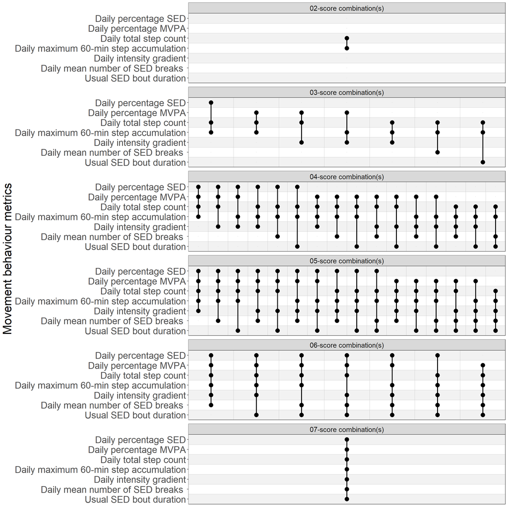

```r
metrics_local_multicomp_profile_graph
```